```python
# %% [markdown]
# # Momentum Físico — BTCUSDT 5m (Señales + Gráfico tipo producción)
#
# En este notebook:
# 1. Descargamos velas de BTCUSDT en 5 minutos desde Binance.
# 2. Calculamos el Momentum Físico (mom, speed, accel, zscores).
# 3. Generamos señales BUY/SELL con los parámetros óptimos.
# 4. Graficamos el precio con marcadores de entrada/salida.

# %%
import pandas as pd
import numpy as np
import requests
import time
from datetime import datetime
import plotly.graph_objects as go

# ===============================
# 0. Configuración general
# ===============================
BASE_URL = "https://api.binance.com"
SYMBOL = "BTCUSDT"
INTERVAL = "5m"

# ======================================================
# 📅 RANGO TEMPORAL REPRODUCIBLE (PAPER)
# ======================================================
START_DATE = "2024-12-01 00:00:00"
END_DATE   = "2025-11-24 23:55:00"

START_TS = int(pd.to_datetime(START_DATE, utc=True).timestamp() * 1000)
END_TS   = int(pd.to_datetime(END_DATE,   utc=True).timestamp() * 1000)

MAX_LIMIT = 1000



# %%
def download_klines_range(
    symbol: str,
    interval: str,
    start_ts: int,
    end_ts: int,
    verbose=True
) -> pd.DataFrame:
    """
    Descarga velas entre start_ts y end_ts (UTC).
    """
    url = f"{BASE_URL}/api/v3/klines"
    all_data = []
    next_start = start_ts

    if verbose:
        print(f"📡 Descargando {symbol} [{interval}] desde {START_DATE} hasta {END_DATE}")

    while True:
        params = {
            "symbol": symbol,
            "interval": interval,
            "limit": MAX_LIMIT,
            "startTime": next_start,
            "endTime": end_ts
        }

        r = requests.get(url, params=params, timeout=10)
        data = r.json()

        if not data or isinstance(data, dict):
            break

        all_data.extend(data)

        last_open_time = data[-1][0]
        next_start = last_open_time + 1

        if last_open_time >= end_ts or len(data) < MAX_LIMIT:
            break

        time.sleep(0.25)

    cols = [
        "Open time", "Open", "High", "Low", "Close", "Volume",
        "Close time", "Quote asset volume", "Number of trades",
        "Taker buy base asset volume", "Taker buy quote asset volume", "Ignore"
    ]

    df = pd.DataFrame(all_data, columns=cols)

    for c in ["Open", "High", "Low", "Close", "Volume"]:
        df[c] = pd.to_numeric(df[c], errors="coerce")

    df["Open time"]  = pd.to_datetime(df["Open time"], unit="ms", utc=True)
    df["Close time"] = pd.to_datetime(df["Close time"], unit="ms", utc=True)

    return df



# %%
# 1) Descargamos BTCUSDT 5m
df_btc_5m = download_klines_range(
    SYMBOL,
    INTERVAL,
    START_TS,
    END_TS,
    verbose=True
)
```

```
📡 Descargando BTCUSDT [5m] desde 2024-12-01 00:00:00 hasta 2025-11-24 23:55:00
```

# Bloques donde generamos banderas y rellenamos los regimenes de compra o venta

```python
## Funciones que nos dan los regimienes de compra/venta y parametros

# ======================================================
# Parámetros óptimos (paper / reproducible)
# ======================================================

PARAMS = {
    "BTCUSDT": {"mom_win": 4, "speed_win": 9, "accel_win": 7, "zspeed_min": 0.3, "zaccel_min": 0.1},
    "ETHUSDT": {"mom_win": 7, "speed_win": 9, "accel_win": 9, "zspeed_min": 0.3, "zaccel_min": 0.2},
    "ADAUSDT": {"mom_win": 4, "speed_win": 7, "accel_win": 5, "zspeed_min": 0.2, "zaccel_min": 0.3},
    "XRPUSDT": {"mom_win": 5, "speed_win": 7, "accel_win": 9, "zspeed_min": 0.2, "zaccel_min": 0.0},
    "BNBUSDT": {"mom_win": 6, "speed_win": 7, "accel_win": 9, "zspeed_min": 0.3, "zaccel_min": 0.0},
}

p = PARAMS["BTCUSDT"]  # activo bajo análisis


def calcular_momentum_fisico_speed(
    df: pd.DataFrame,
    mom_win: int,
    speed_win: int,
    accel_win: int
) -> pd.DataFrame:

    df = df.copy()

    # 1) Momentum (primera derivada)
    df["mom"] = df["Close"].diff()

    # Suavizado del momentum
    df["mom_smooth"] = df["mom"].rolling(mom_win, min_periods=1).mean()

    # 2) Speed (derivada de mom_smooth)
    df["speed"] = df["mom_smooth"].diff()

    # Suavizado robusto de speed (mediana)
    df["speed_smooth"] = df["speed"].rolling(speed_win, min_periods=1).median()

    # 3) Accel (derivada de speed_smooth)
    df["accel"] = df["speed_smooth"].diff()

    # Suavizado robusto de accel (mediana)
    df["accel_smooth"] = df["accel"].rolling(accel_win, min_periods=1).median()

    # 4) Z-scores (normalización por volatilidad local)
    std_speed = df["speed_smooth"].rolling(30).std()
    std_accel = df["accel_smooth"].rolling(30).std()

    # Evitar divisiones por cero
    std_speed = std_speed.replace(0, np.nan)
    std_accel = std_accel.replace(0, np.nan)

    df["zspeed"] = df["speed_smooth"] / std_speed
    df["zaccel"] = df["accel_smooth"] / std_accel

    # ⛔ ANTES: esto borraba filas enteras y creaba huecos
    # df = df.dropna().reset_index(drop=True)

    # ✔ AHORA: rellenamos NaN con 0 para no eliminar velas
    df["zspeed"] = df["zspeed"].fillna(0)
    df["zaccel"] = df["zaccel"].fillna(0)

    # Sólo reseteamos índice sin borrar nada
    df = df.reset_index(drop=True)

    return df



def generar_senales_fisico(
    df: pd.DataFrame,
    zspeed_min: float,
    zaccel_min: float
) -> pd.DataFrame:
    """
    Genera banderas BUY/SELL basadas en:
    - Cruces de zspeed (speed smooth normalizado)
    - Confirmación de zaccel (accel normalizada)
    - Una sola posición activa a la vez
    """
    df = df.copy()

    # Condiciones "crudas"
    df["buy_raw"] = (
        (df["zspeed"].shift(1) < 0) &
        (df["zspeed"] > zspeed_min) &
        (df["zaccel"] > zaccel_min)
    )

    df["sell_raw"] = (
        (df["zspeed"].shift(1) > 0) &
        (df["zspeed"] < -zspeed_min) &
        (df["zaccel"] < -zaccel_min)
    )

    # Bandera única de posición
    in_pos = False
    BUY, SELL = [], []

    for i in range(len(df)):
        if df.loc[i, "buy_raw"] and not in_pos:
            BUY.append(True)
            SELL.append(False)
            in_pos = True

        elif df.loc[i, "sell_raw"] and in_pos:
            BUY.append(False)
            SELL.append(True)
            in_pos = False

        else:
            BUY.append(False)
            SELL.append(False)

    df["BUY"] = BUY
    df["SELL"] = SELL

    return df
```

```python
# ======================================================
# 2) Generación de señales BUY / SELL (eventos)
# ======================================================

# ======================================================
# 2a) Cálculo de Momentum Físico (features)
# ======================================================

df_feat = calcular_momentum_fisico_speed(
    df_btc_5m,
    mom_win=p["mom_win"],
    speed_win=p["speed_win"],
    accel_win=p["accel_win"]
)



# ======================================================
# 2b) Generación de señales BUY / SELL (eventos)
# ======================================================

df_signals = generar_senales_fisico(
    df_feat,
    zspeed_min=p["zspeed_min"],
    zaccel_min=p["zaccel_min"]
)


# Verificación rápida (opcional)
print("BUY signals:", df_signals["BUY"].sum())
print("SELL signals:", df_signals["SELL"].sum())
```

```
BUY signals: 398
SELL signals: 398
```

```python
# ======================================================
# 3) Construcción de régimen continuo BUY / SELL
# ======================================================

df_regime = df_signals.copy()

regime = 0   # 0 = SELL / fuera, 1 = BUY / dentro
regimes = []

for i in range(len(df_regime)):
    if df_regime.loc[i, "BUY"]:
        regime = 1
    elif df_regime.loc[i, "SELL"]:
        regime = 0

    regimes.append(regime)

df_regime["regime"] = regimes
```

```python
df_regime["regime"].value_counts(normalize=True)
```

```
regime
0    0.513328
1    0.486672
Name: proportion, dtype: float64
```

```python
df_regime[["Open time", "Close", "BUY", "SELL", "regime"]].tail(50)
```

|  | Open time | Close | BUY | SELL | regime |
| --- | --- | --- | --- | --- | --- |
| 103342 | 2025-11-24 19:50:00+00:00 | 88162.59 | False | False | 1 |
| 103343 | 2025-11-24 19:55:00+00:00 | 88327.29 | False | False | 1 |
| 103344 | 2025-11-24 20:00:00+00:00 | 88503.99 | False | False | 1 |
| 103345 | 2025-11-24 20:05:00+00:00 | 88584.68 | False | False | 1 |
| 103346 | 2025-11-24 20:10:00+00:00 | 88649.20 | False | False | 1 |
| 103347 | 2025-11-24 20:15:00+00:00 | 88779.08 | False | False | 1 |
| 103348 | 2025-11-24 20:20:00+00:00 | 88740.66 | False | False | 1 |
| 103349 | 2025-11-24 20:25:00+00:00 | 88884.61 | False | False | 1 |
| 103350 | 2025-11-24 20:30:00+00:00 | 88818.53 | False | False | 1 |
| 103351 | 2025-11-24 20:35:00+00:00 | 88913.29 | False | False | 1 |
| 103352 | 2025-11-24 20:40:00+00:00 | 88939.66 | False | False | 1 |
| 103353 | 2025-11-24 20:45:00+00:00 | 89106.87 | False | False | 1 |
| 103354 | 2025-11-24 20:50:00+00:00 | 89227.99 | False | False | 1 |
| 103355 | 2025-11-24 20:55:00+00:00 | 89089.06 | False | False | 1 |
| 103356 | 2025-11-24 21:00:00+00:00 | 89031.80 | False | False | 1 |
| 103357 | 2025-11-24 21:05:00+00:00 | 89076.20 | False | False | 1 |
| 103358 | 2025-11-24 21:10:00+00:00 | 89047.14 | False | False | 1 |
| 103359 | 2025-11-24 21:15:00+00:00 | 88941.32 | False | False | 1 |
| 103360 | 2025-11-24 21:20:00+00:00 | 88920.16 | False | False | 1 |
| 103361 | 2025-11-24 21:25:00+00:00 | 88917.31 | False | True | 0 |
| 103362 | 2025-11-24 21:30:00+00:00 | 88970.20 | False | False | 0 |
| 103363 | 2025-11-24 21:35:00+00:00 | 88867.38 | False | False | 0 |
| 103364 | 2025-11-24 21:40:00+00:00 | 88775.53 | False | False | 0 |
| 103365 | 2025-11-24 21:45:00+00:00 | 88801.36 | False | False | 0 |
| 103366 | 2025-11-24 21:50:00+00:00 | 88750.43 | False | False | 0 |
| 103367 | 2025-11-24 21:55:00+00:00 | 88766.15 | False | False | 0 |
| 103368 | 2025-11-24 22:00:00+00:00 | 88893.66 | False | False | 0 |
| 103369 | 2025-11-24 22:05:00+00:00 | 88953.99 | False | False | 0 |
| 103370 | 2025-11-24 22:10:00+00:00 | 89035.49 | False | False | 0 |
| 103371 | 2025-11-24 22:15:00+00:00 | 88923.39 | False | False | 0 |
| 103372 | 2025-11-24 22:20:00+00:00 | 88785.52 | False | False | 0 |
| 103373 | 2025-11-24 22:25:00+00:00 | 88784.35 | False | False | 0 |
| 103374 | 2025-11-24 22:30:00+00:00 | 88879.99 | False | False | 0 |
| 103375 | 2025-11-24 22:35:00+00:00 | 88838.33 | False | False | 0 |
| 103376 | 2025-11-24 22:40:00+00:00 | 88844.39 | False | False | 0 |
| 103377 | 2025-11-24 22:45:00+00:00 | 88747.58 | False | False | 0 |
| 103378 | 2025-11-24 22:50:00+00:00 | 88615.20 | False | False | 0 |
| 103379 | 2025-11-24 22:55:00+00:00 | 88636.54 | False | False | 0 |
| 103380 | 2025-11-24 23:00:00+00:00 | 88600.00 | False | False | 0 |
| 103381 | 2025-11-24 23:05:00+00:00 | 88520.01 | False | False | 0 |
| 103382 | 2025-11-24 23:10:00+00:00 | 88522.00 | False | False | 0 |
| 103383 | 2025-11-24 23:15:00+00:00 | 88604.86 | False | False | 0 |
| 103384 | 2025-11-24 23:20:00+00:00 | 88534.23 | False | False | 0 |
| 103385 | 2025-11-24 23:25:00+00:00 | 88617.55 | False | False | 0 |
| 103386 | 2025-11-24 23:30:00+00:00 | 88513.50 | False | False | 0 |
| 103387 | 2025-11-24 23:35:00+00:00 | 88331.54 | False | False | 0 |
| 103388 | 2025-11-24 23:40:00+00:00 | 88428.56 | False | False | 0 |
| 103389 | 2025-11-24 23:45:00+00:00 | 88330.06 | False | False | 0 |
| 103390 | 2025-11-24 23:50:00+00:00 | 88271.06 | False | False | 0 |
| 103391 | 2025-11-24 23:55:00+00:00 | 88300.01 | False | False | 0 |

# Procedemos con el analisis de los regimenes de compra o venta para su evaluacion

```python
# ======================================================
# 4) Identificación y diagnóstico de regímenes BUY (regime=1)
# ======================================================
# Objetivo:
# - Convertir el "regime continuo" en segmentos (bloques) de BUY-regime.
# - Para cada bloque, medir métricas internas:
#   * retorno realizado (entry -> exit)
#   * MFE: Maximum Favorable Excursion (mejor movimiento a favor dentro del régimen)
#   * MAE: Maximum Adverse Excursion (peor movimiento en contra dentro del régimen)
#   * max drawdown interno (desde el pico interno hasta el final)
#   * "giveback" (cuánto profit se devolvió desde el pico hasta el exit)
# - Etiquetar regímenes como:
#   * GOOD: exit_return > 0
#   * BAD: exit_return <= 0
#   * IMPROVE_EXIT: hubo MFE positivo razonable pero el exit devolvió demasiado o terminó negativo
#
# Nota: aquí NO estamos optimizando señales, solo diagnosticando.
# ======================================================

def extraer_regimenes_buy(df: pd.DataFrame) -> pd.DataFrame:
    """
    Extrae segmentos donde regime=1 (BUY-regime) y calcula métricas internas por segmento.

    Requisitos del df:
    - Debe contener columnas: ["Open time", "High", "Low", "Close", "regime"]
    - "Open time" debe estar en datetime (idealmente UTC como ya lo tienes).

    Devuelve:
    - Un DataFrame 'regimes' con una fila por BUY-regime (segmento continuo).
    """
    df = df.copy().reset_index(drop=True)

    # --------------------------------------------------
    # 1) Identificar cambios de régimen para crear un id de segmento
    #    Cada vez que cambia 'regime' (0->1 o 1->0) se incrementa el contador.
    # --------------------------------------------------
    df["regime_change"] = df["regime"].ne(df["regime"].shift(1)).astype(int)
    df["segment_id"] = df["regime_change"].cumsum()

    # Nos quedamos solo con segmentos BUY (regime=1)
    df_buy = df[df["regime"] == 1].copy()

    # Si por alguna razón no hay segmentos BUY, devolvemos vacío
    if df_buy.empty:
        return pd.DataFrame()

    # --------------------------------------------------
    # 2) Agrupar por segmento BUY y calcular métricas
    # --------------------------------------------------
    out = []

    for seg_id, g in df_buy.groupby("segment_id"):
        g = g.sort_values("Open time").reset_index(drop=True)

        # ----- Entry / Exit (definición base) -----
        entry_time = g.loc[0, "Open time"]
        exit_time   = g.loc[len(g) - 1, "Open time"]

        entry_price = g.loc[0, "Close"]
        exit_price  = g.loc[len(g) - 1, "Close"]

        # Duración del régimen (en velas y en minutos)
        n_bars = len(g)
        duration_minutes = n_bars * 5  # porque estamos en 5m

        # Retorno realizado (close-to-close) del régimen
        exit_return = (exit_price - entry_price) / entry_price

        # ----- Métricas internas: MFE / MAE -----
        # MFE: máximo (High) alcanzado relativo al entry
        peak_price = g["High"].max()
        peak_idx = g["High"].idxmax()
        peak_time = g.loc[peak_idx, "Open time"]

        mfe = (peak_price - entry_price) / entry_price

        # MAE: mínimo (Low) alcanzado relativo al entry
        trough_price = g["Low"].min()
        trough_idx = g["Low"].idxmin()
        trough_time = g.loc[trough_idx, "Open time"]

        mae = (trough_price - entry_price) / entry_price  # (normalmente será negativo)

        # ----- Giveback: cuánto se devolvió desde el pico hasta el exit -----
        # Si hubo un pico por encima del entry, cuánto de ese "upside" se perdió al salir.
        # giveback_ratio = (peak_price - exit_price) / (peak_price - entry_price)
        # (solo tiene sentido si peak_price > entry_price)
        if peak_price > entry_price:
            giveback_ratio = (peak_price - exit_price) / (peak_price - entry_price)
            # clamp razonable para interpretar (puede ser >1 si exit queda bajo entry)
            # pero lo dejamos como está porque puede ser informativo.
        else:
            giveback_ratio = 0.0

        # ----- Max drawdown interno después del pico -----
        # Idea: desde el pico interno (peak_idx) hacia adelante,
        # ver la caída más grande desde máximos acumulados.
        post = g.loc[peak_idx:].copy()
        if len(post) >= 2:
            running_max = post["Close"].cummax()
            dd_series = (post["Close"] - running_max) / running_max
            max_drawdown_post_peak = dd_series.min()  # valor negativo
        else:
            max_drawdown_post_peak = 0.0

        out.append({
            "segment_id": int(seg_id),
            "entry_time": entry_time,
            "exit_time": exit_time,
            "n_bars": int(n_bars),
            "duration_minutes": int(duration_minutes),
            "entry_price": float(entry_price),
            "exit_price": float(exit_price),
            "exit_return": float(exit_return),

            "peak_time": peak_time,
            "peak_price": float(peak_price),
            "mfe": float(mfe),

            "trough_time": trough_time,
            "trough_price": float(trough_price),
            "mae": float(mae),

            "giveback_ratio": float(giveback_ratio),
            "max_drawdown_post_peak": float(max_drawdown_post_peak),
        })

    regimes = pd.DataFrame(out)

    # --------------------------------------------------
    # 3) Etiquetas simples y útiles para diagnóstico
    # --------------------------------------------------
    # GOOD vs BAD (baseline)
    regimes["label_good"] = regimes["exit_return"] > 0

    # "Candidate to improve exit":
    # - Hubo movimiento favorable interno (mfe) pero el exit fue pobre
    #   (salimos negativo o devolvimos mucho).
    #
    # Umbrales sugeridos (puedes ajustarlos luego):
    # - mfe >= +0.20% (0.002) para decir que "sí hubo oportunidad"
    # - y (exit_return <= 0) o giveback_ratio >= 0.60 (devolvió 60% o más del upside)
    mfe_min = 0.002
    giveback_thr = 0.60

    regimes["label_improve_exit"] = (
        (regimes["mfe"] >= mfe_min) &
        ((regimes["exit_return"] <= 0) | (regimes["giveback_ratio"] >= giveback_thr))
    )

    return regimes


# ======================================================
# Ejecutar Paso 4
# ======================================================
regimes_btc = extraer_regimenes_buy(df_regime)

print("BUY-regimes detectados:", len(regimes_btc))
print("GOOD ratio (%):", round(regimes_btc["label_good"].mean() * 100, 2))
print("IMPROVE_EXIT ratio (%):", round(regimes_btc["label_improve_exit"].mean() * 100, 2))

# Vista rápida de los peores regímenes (por exit_return)
regimes_btc.sort_values("exit_return").head(10)
```

```
BUY-regimes detectados: 398
GOOD ratio (%): 58.54
IMPROVE_EXIT ratio (%): 36.68
```

|  | segment_id | entry_time | exit_time | n_bars | duration_minutes | entry_price | exit_price | exit_return | peak_time | peak_price | mfe | trough_time | trough_price | mae | giveback_ratio | max_drawdown_post_peak | label_good | label_improve_exit |
| --- | --- | --- | --- | --- | --- | --- | --- | --- | --- | --- | --- | --- | --- | --- | --- | --- | --- | --- |
| 391 | 784 | 2025-11-20 13:25:00+00:00 | 2025-11-21 10:50:00+00:00 | 258 | 1290 | 91917.97 | 82708.03 | -0.100197 | 2025-11-20 13:30:00+00:00 | 92541.92 | 0.006788 | 2025-11-21 10:15:00+00:00 | 81648.00 | -0.111730 | 15.760702 | -0.110163 | False | True |
| 346 | 694 | 2025-10-10 12:55:00+00:00 | 2025-10-11 04:20:00+00:00 | 186 | 930 | 121597.21 | 112463.65 | -0.075113 | 2025-10-10 13:35:00+00:00 | 122550.00 | 0.007836 | 2025-10-10 21:20:00+00:00 | 102000.00 | -0.161165 | 10.586121 | -0.150687 | False | True |
| 40 | 82 | 2025-01-07 09:45:00+00:00 | 2025-01-08 18:30:00+00:00 | 394 | 1970 | 101705.70 | 94529.36 | -0.070560 | 2025-01-07 09:55:00+00:00 | 101769.93 | 0.000632 | 2025-01-08 17:30:00+00:00 | 92500.90 | -0.090504 | 112.728787 | -0.085593 | False | False |
| 94 | 190 | 2025-02-26 06:30:00+00:00 | 2025-02-26 18:45:00+00:00 | 148 | 740 | 88824.77 | 84402.00 | -0.049792 | 2025-02-26 10:55:00+00:00 | 89314.45 | 0.005513 | 2025-02-26 18:35:00+00:00 | 83418.00 | -0.060870 | 10.031960 | -0.063876 | False | True |
| 93 | 188 | 2025-02-23 05:35:00+00:00 | 2025-02-25 04:55:00+00:00 | 569 | 2845 | 96283.53 | 91900.01 | -0.045527 | 2025-02-23 07:40:00+00:00 | 96558.01 | 0.002851 | 2025-02-25 00:10:00+00:00 | 90912.01 | -0.055789 | 16.970271 | -0.057493 | False | True |
| 59 | 120 | 2025-01-26 17:10:00+00:00 | 2025-01-27 16:30:00+00:00 | 281 | 1405 | 104999.99 | 100371.99 | -0.044076 | 2025-01-26 18:25:00+00:00 | 105260.36 | 0.002480 | 2025-01-27 07:25:00+00:00 | 97777.77 | -0.068783 | 18.774705 | -0.070526 | False | True |
| 102 | 206 | 2025-03-08 22:35:00+00:00 | 2025-03-10 05:30:00+00:00 | 372 | 1860 | 86183.63 | 82390.15 | -0.044016 | 2025-03-09 01:05:00+00:00 | 86500.00 | 0.003671 | 2025-03-09 23:05:00+00:00 | 80000.00 | -0.071749 | 12.990644 | -0.073060 | False | True |
| 388 | 778 | 2025-11-17 11:15:00+00:00 | 2025-11-18 00:35:00+00:00 | 161 | 805 | 95768.29 | 91715.61 | -0.042318 | 2025-11-17 14:35:00+00:00 | 96043.00 | 0.002868 | 2025-11-17 22:25:00+00:00 | 91220.00 | -0.047493 | 15.752575 | -0.043434 | False | True |
| 104 | 210 | 2025-03-10 11:00:00+00:00 | 2025-03-10 20:10:00+00:00 | 111 | 555 | 82361.41 | 78936.02 | -0.041590 | 2025-03-10 11:55:00+00:00 | 83826.02 | 0.017783 | 2025-03-10 19:00:00+00:00 | 77459.91 | -0.059512 | 3.338773 | -0.073882 | False | True |
| 52 | 106 | 2025-01-20 10:15:00+00:00 | 2025-01-20 17:10:00+00:00 | 84 | 420 | 108243.32 | 104231.73 | -0.037061 | 2025-01-20 10:20:00+00:00 | 108731.92 | 0.004514 | 2025-01-20 17:05:00+00:00 | 101401.01 | -0.063212 | 9.210377 | -0.041064 | False | True |

## Nuestros resultados muestran que aproximadamente el 36.7% de los regímenes BUY presentan un movimiento interno de precio favorable significativo pero no lo materializan al salir, lo que indica que la principal ineficiencia de la estrategia base radica en el momento de salida más que en la detección de entradas.

```python
# ======================================================
# 4.1) Añadir segment_id por vela (para extracción visual)
# ======================================================

df_viz = df_regime.copy()

# Repetimos la lógica de segmentación
df_viz["regime_change"] = df_viz["regime"].ne(df_viz["regime"].shift(1)).astype(int)
df_viz["segment_id"] = df_viz["regime_change"].cumsum()

# Confirmación rápida
df_viz[["Open time", "regime", "segment_id"]].head(10)
```

|  | Open time | regime | segment_id |
| --- | --- | --- | --- |
| 0 | 2024-12-01 00:00:00+00:00 | 0 | 1 |
| 1 | 2024-12-01 00:05:00+00:00 | 0 | 1 |
| 2 | 2024-12-01 00:10:00+00:00 | 0 | 1 |
| 3 | 2024-12-01 00:15:00+00:00 | 0 | 1 |
| 4 | 2024-12-01 00:20:00+00:00 | 0 | 1 |
| 5 | 2024-12-01 00:25:00+00:00 | 0 | 1 |
| 6 | 2024-12-01 00:30:00+00:00 | 0 | 1 |
| 7 | 2024-12-01 00:35:00+00:00 | 0 | 1 |
| 8 | 2024-12-01 00:40:00+00:00 | 0 | 1 |
| 9 | 2024-12-01 00:45:00+00:00 | 0 | 1 |

```python
# ======================================================
# 4.2) Selección de regímenes representativos
# ======================================================

# GOOD regimes (positivos y sin gran giveback)
good_ids = (
    regimes_btc
    .query("label_good == True")
    .sort_values("exit_return", ascending=False)
    .head(3)["segment_id"]
    .tolist()
)

# IMPROVE_EXIT regimes (hubo oportunidad pero mala salida)
improve_ids = (
    regimes_btc
    .query("label_improve_exit == True")
    .sort_values("giveback_ratio", ascending=False)
    .head(3)["segment_id"]
    .tolist()
)

print("GOOD regime IDs:", good_ids)
print("IMPROVE_EXIT regime IDs:", improve_ids)
```

```
GOOD regime IDs: [202, 676, 102]
IMPROVE_EXIT regime IDs: [120, 188, 784]
```

```python
import matplotlib.pyplot as plt

# ======================================================
# 4.3) Función para graficar un BUY-regime completo (Matplotlib)
# ======================================================

def plot_buy_regime_matplotlib(
    df: pd.DataFrame,
    segment_id: int,
    title_suffix: str = "",
    save_path: str | None = None
):
    """
    Grafica un régimen BUY completo:
    - Precio (Close)
    - zspeed y zaccel
    - Marca entry, peak y exit

    Si save_path no es None, guarda el gráfico como PNG/PDF.
    """

    g = df[df["segment_id"] == segment_id].copy()
    g = g.sort_values("Open time")

    if g.empty:
        print(f"Segment {segment_id} vacío")
        return

    # -----------------------------
    # Entry / Exit
    # -----------------------------
    entry_time  = g.iloc[0]["Open time"]
    exit_time   = g.iloc[-1]["Open time"]
    entry_price = g.iloc[0]["Close"]
    exit_price  = g.iloc[-1]["Close"]

    # -----------------------------
    # Peak
    # -----------------------------
    peak_idx   = g["High"].idxmax()
    peak_time  = g.loc[peak_idx, "Open time"]
    peak_price = g.loc[peak_idx, "High"]

    # -----------------------------
    # Figure & Axes
    # -----------------------------
    fig, ax_price = plt.subplots(figsize=(10, 5))

    # ---- Precio ----
    ax_price.plot(
        g["Open time"],
        g["Close"],
        label="Close Price",
        linewidth=2
    )

    # Entry
    ax_price.scatter(
        entry_time,
        entry_price,
        color="green",
        marker="^",
        s=80,
        label="BUY",
        zorder=5
    )

    # Peak
    ax_price.scatter(
        peak_time,
        peak_price,
        color="orange",
        marker="*",
        s=120,
        label="PEAK",
        zorder=6
    )

    # Exit
    ax_price.scatter(
        exit_time,
        exit_price,
        color="red",
        marker="v",
        s=80,
        label="SELL",
        zorder=5
    )

    ax_price.set_xlabel("Time")
    ax_price.set_ylabel("Price")

    # -----------------------------
    # Secondary axis (z-scores)
    # -----------------------------
    ax_z = ax_price.twinx()

    ax_z.plot(
        g["Open time"],
        g["zspeed"],
        linestyle=":",
        linewidth=1.8,
        label="zspeed"
    )

    ax_z.plot(
        g["Open time"],
        g["zaccel"],
        linestyle="--",
        linewidth=1.8,
        label="zaccel"
    )

    ax_z.set_ylabel("z-score")

    # -----------------------------
    # Title & Legend
    # -----------------------------
    fig.suptitle(f"BUY Regime {segment_id} {title_suffix}", fontsize=12)

    # Merge legends from both axes
    handles_1, labels_1 = ax_price.get_legend_handles_labels()
    handles_2, labels_2 = ax_z.get_legend_handles_labels()

    ax_price.legend(
        handles_1 + handles_2,
        labels_1 + labels_2,
        loc="upper left",
        fontsize=9
    )

    fig.tight_layout()
```

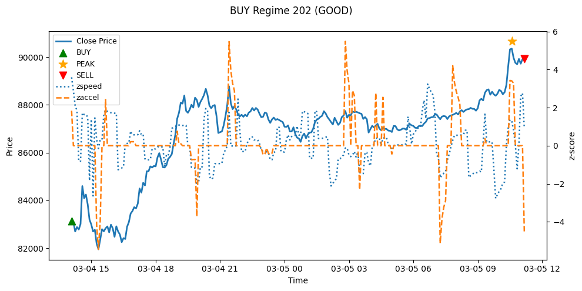

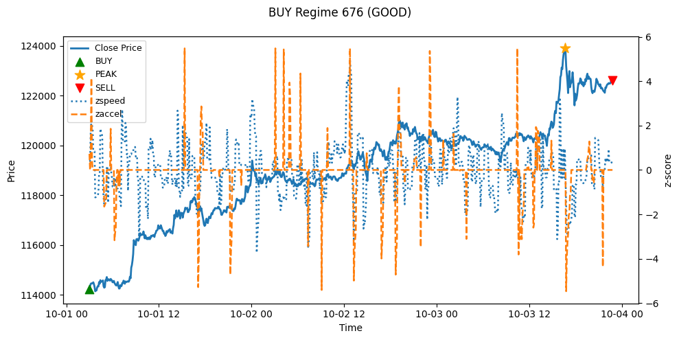

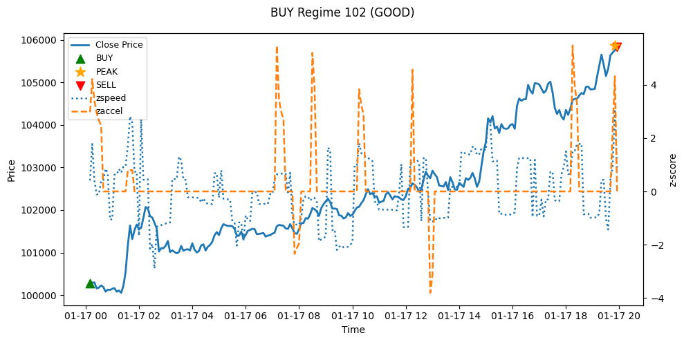

```python
for sid in good_ids:
    plot_buy_regime_matplotlib(
        df_viz,
        sid,
        title_suffix="(GOOD)",
        save_path=f"figures/buy_regime_{sid}_good.png"
    )
```

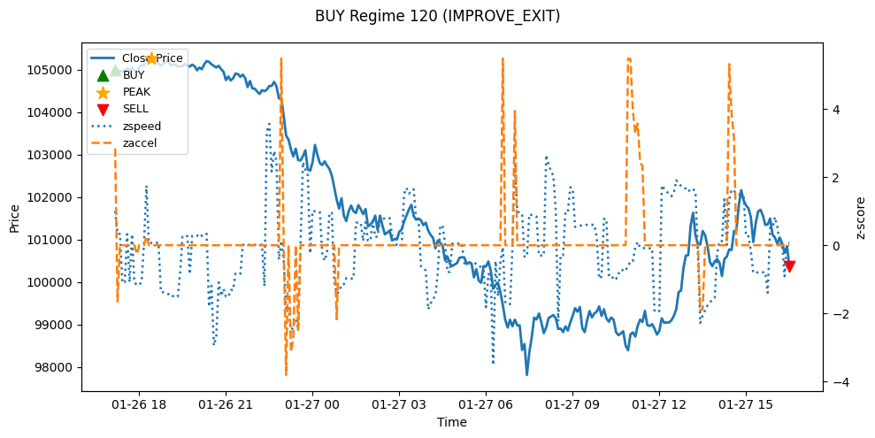

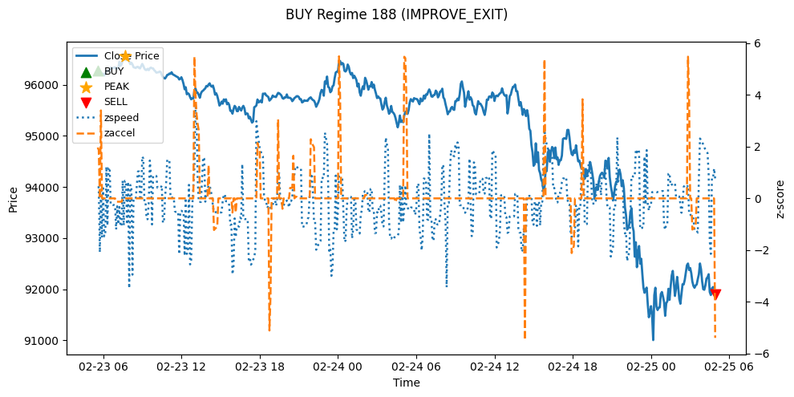

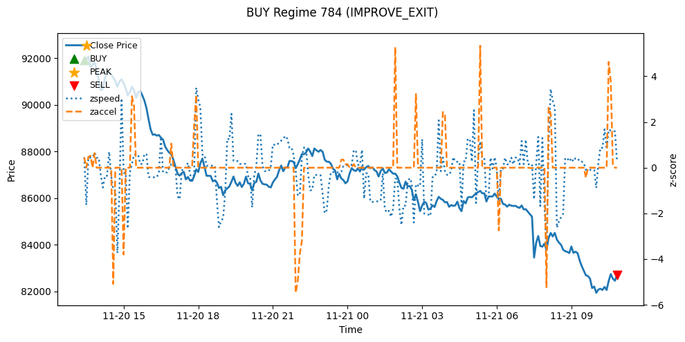

```python
for sid in improve_ids:
    plot_buy_regime_matplotlib(
        df_viz,
        sid,
        title_suffix="(IMPROVE_EXIT)",
        save_path=f"figures/buy_regime_{sid}_improve.png"
    )
```

```python
# ===============================
# A) Export: resumen por régimen
# ===============================

# regimes_btc ya lo tienes del Paso 4
regimes_btc.to_csv("regimes_summary_btc_5m.csv", index=False)
print("✅ Guardado: regimes_summary_btc_5m.csv")
```

```
✅ Guardado: regimes_summary_btc_5m.csv
```

#### Con solo este resumen ya se puede afirmar:

#### La estrategia base identifica correctamente oportunidades direccionales, como lo demuestran las excursiones internas de precio (MFE) consistentemente positivas. Sin embargo, la devolución excesiva de beneficios y los periodos prolongados de permanencia deterioran significativamente los retornos realizados, lo que indica que el momento de salida —más que la detección de entradas— es la principal fuente de ineficiencia.

#### Esto justifica completamente:

#### - el enfoque por regímenes,

#### - y el rediseño de las salidas.

```python
import os

# ======================================================
# C) Export: velas por régimen (un CSV por segmento)
# ======================================================

EXPORT_DIR = "regime_exports_btc"
os.makedirs(EXPORT_DIR, exist_ok=True)

cols_export = [
    "Open time","Open","High","Low","Close","Volume",
    "mom","mom_smooth","speed","speed_smooth","accel","accel_smooth",
    "zspeed","zaccel",
    "BUY","SELL","regime","segment_id"
]

def export_regime_csv(df_viz: pd.DataFrame, segment_id: int, prefix: str):
    g = df_viz[df_viz["segment_id"] == segment_id].copy().sort_values("Open time")
    g[cols_export].to_csv(f"{EXPORT_DIR}/{prefix}_seg{segment_id}.csv", index=False)

# Exporta ambos grupos
for sid in improve_ids:
    export_regime_csv(df_viz, sid, prefix="IMPROVE")

for sid in good_ids:
    export_regime_csv(df_viz, sid, prefix="GOOD")

print(f"✅ Exportados CSVs a: {EXPORT_DIR}/")
```

```
✅ Exportados CSVs a: regime_exports_btc/
```

### Empezamos refinamienot de regimemensde improve exit

```python
# ======================================================
# Selección de IMPROVE_EXIT tipo B (late exit)
# ======================================================

late_exit_ids = (
    regimes_btc
    .query(
        "label_improve_exit == True "
        "and mfe >= 0.01 "
        "and giveback_ratio >= 0.6"
    )
    .sort_values("giveback_ratio", ascending=False)
    .head(5)["segment_id"]
    .tolist()
)

late_exit_ids
```

```
[210, 104, 140, 280, 24]
```

```python
# ======================================================
# Export CSVs: IMPROVE_EXIT tipo B (late exit)
# ======================================================

EXPORT_DIR = "regime_exports_btc_late_exit"
os.makedirs(EXPORT_DIR, exist_ok=True)

cols_export = [
    "Open time","Open","High","Low","Close","Volume",
    "mom","mom_smooth","speed","speed_smooth",
    "accel","accel_smooth",
    "zspeed","zaccel",
    "BUY","SELL","regime","segment_id"
]

def export_regime_csv(df_viz, segment_id, prefix):
    g = (
        df_viz[df_viz["segment_id"] == segment_id]
        .copy()
        .sort_values("Open time")
    )
    g[cols_export].to_csv(
        f"{EXPORT_DIR}/{prefix}_seg{segment_id}.csv",
        index=False
    )

for sid in late_exit_ids:
    export_regime_csv(df_viz, sid, prefix="LATE_EXIT")

print("✅ Exportados LATE_EXIT regimes:", late_exit_ids)
```

```
✅ Exportados LATE_EXIT regimes: [210, 104, 140, 280, 24]
```

```python
# ======================================================
# Bundle CSV con todos los LATE_EXIT
# ======================================================

bundle_late_exit = (
    df_viz[df_viz["segment_id"].isin(late_exit_ids)]
    .copy()
    .sort_values(["segment_id", "Open time"])
)

bundle_late_exit[cols_export].to_csv(
    "btc_5m_late_exit_bundle.csv",
    index=False
)

print("✅ Guardado: btc_5m_late_exit_bundle.csv")
```

```
✅ Guardado: btc_5m_late_exit_bundle.csv
```

### In late-exit regimes, the price peak systematically occurs after momentum has already begun to decay. The strategy fails not because of incorrect entry or lack of directional movement, but because exit decisions are delayed until after the underlying dynamic has already reversed.

```python
from pathlib import Path

def _find_col(df, candidates):
    """Return first matching column from candidates list (case-insensitive)."""
    lower_map = {c.lower(): c for c in df.columns}
    for cand in candidates:
        if cand.lower() in lower_map:
            return lower_map[cand.lower()]
    return None

def compute_max_drawdown(equity: pd.Series):
    """
    equity: Series of cumulative equity (e.g., 1.0 * cumprod(1+ret))
    returns: max_drawdown (negative), drawdown_series
    """
    equity = equity.astype(float)
    peak = equity.cummax()
    dd = equity / peak - 1.0
    return float(dd.min()), dd

def compute_recovery_factor(total_return_compound: float, max_drawdown: float):
    # total_return_compound is positive (e.g. 0.46), max_drawdown is negative (e.g. -0.11)
    if max_drawdown >= 0:
        return np.nan
    return float(total_return_compound / abs(max_drawdown))

def compound_return_from_trade_rets(rets: pd.Series):
    # rets are decimal returns per trade (e.g., 0.002 = 0.2%)
    return float((1.0 + rets.fillna(0).astype(float)).prod() - 1.0)

def safe_mean(x):
    x = pd.to_numeric(x, errors="coerce")
    return float(x.mean())

def safe_median(x):
    x = pd.to_numeric(x, errors="coerce")
    return float(x.median())

def pct(x):
    return 100.0 * float(x)
```

```python
# Ajusta paths si hace falta
trades_path = Path("trades_compare_baseline_vs_hybrid.csv")
eq_base_path = Path("equity_baseline_btc_5m.csv")
eq_hyb_path  = Path("equity_hybrid_btc_5m.csv")
regimes_path = Path("regimes_summary_btc_5m.csv")

assert trades_path.exists(), f"No encuentro {trades_path.resolve()}"
assert eq_base_path.exists(), f"No encuentro {eq_base_path.resolve()}"
assert eq_hyb_path.exists(),  f"No encuentro {eq_hyb_path.resolve()}"

trades = pd.read_csv(trades_path)
eq_base = pd.read_csv(eq_base_path)
eq_hyb  = pd.read_csv(eq_hyb_path)

regimes = None
if regimes_path.exists():
    regimes = pd.read_csv(regimes_path)

print("✅ Trades rows:", trades.shape)
print("✅ Equity baseline rows:", eq_base.shape)
print("✅ Equity hybrid rows:", eq_hyb.shape)
print("✅ Regimes summary loaded:", regimes.shape if regimes is not None else "No (optional)")
```

```
✅ Trades rows: (398, 16)
✅ Equity baseline rows: (398, 7)
✅ Equity hybrid rows: (398, 13)
✅ Regimes summary loaded: (398, 18)
```

```python
# ======================================================
# Celda 3 (FIXED): Mapear columnas reales del CSV
# ======================================================

# Retornos
col_ret_base = "exit_return_baseline"
col_ret_hyb  = "exit_return_hybrid"

assert col_ret_base in trades.columns, f"Falta columna {col_ret_base}"
assert col_ret_hyb  in trades.columns, f"Falta columna {col_ret_hyb}"

# Giveback x MFE (ya vienen en tu CSV)
col_gb_base = "giveback_x_mfe_baseline"
col_gb_hyb  = "giveback_x_mfe_hybrid"
assert col_gb_base in trades.columns, f"Falta columna {col_gb_base}"
assert col_gb_hyb  in trades.columns, f"Falta columna {col_gb_hyb}"

# Flags híbridos
col_det   = "used_deterioration"
col_early = "exited_early"
col_frag  = "fragile"

assert col_det in trades.columns, f"Falta columna {col_det}"
assert col_early in trades.columns, f"Falta columna {col_early}"
assert col_frag in trades.columns, f"Falta columna {col_frag}"

# Outcome: si no existe explícito, lo inferimos del retorno > 0
trades["baseline_outcome"] = np.where(pd.to_numeric(trades[col_ret_base], errors="coerce") > 0, "WIN", "LOSS")
trades["hybrid_outcome"]   = np.where(pd.to_numeric(trades[col_ret_hyb],  errors="coerce") > 0, "WIN", "LOSS")

col_out_base = "baseline_outcome"
col_out_hyb  = "hybrid_outcome"

print("✅ Mapeo listo")
print("RET:", col_ret_base, col_ret_hyb)
print("GB :", col_gb_base, col_gb_hyb)
print("FLAGS:", col_det, col_early, col_frag)
```

```
✅ Mapeo listo
RET: exit_return_baseline exit_return_hybrid
GB : giveback_x_mfe_baseline giveback_x_mfe_hybrid
FLAGS: used_deterioration exited_early fragile
```

```python
# ======================================================
# Celda 4 (Paper Summary): métricas principales
# ======================================================

base_rets = pd.to_numeric(trades[col_ret_base], errors="coerce")
hyb_rets  = pd.to_numeric(trades[col_ret_hyb],  errors="coerce")

n_trades = int(len(trades))

base_winrate = (trades[col_out_base] == "WIN").mean()
hyb_winrate  = (trades[col_out_hyb]  == "WIN").mean()

base_avg = float(base_rets.mean())
hyb_avg  = float(hyb_rets.mean())

base_med = float(base_rets.median())
hyb_med  = float(hyb_rets.median())

base_comp = float((1.0 + base_rets.fillna(0)).prod() - 1.0)
hyb_comp  = float((1.0 + hyb_rets.fillna(0)).prod() - 1.0)

# Giveback x MFE (ya viene calculado)
base_gb = float(pd.to_numeric(trades[col_gb_base], errors="coerce").mean())
hyb_gb  = float(pd.to_numeric(trades[col_gb_hyb],  errors="coerce").mean())
gb_reduction = 100.0 * (1.0 - (hyb_gb / base_gb))

# % deterioro y % early exits
det_rate   = float(pd.to_numeric(trades[col_det],   errors="coerce").mean())
early_rate = float(pd.to_numeric(trades[col_early], errors="coerce").mean())

summary = pd.DataFrame([
    {
        "model": "Baseline",
        "trades": n_trades,
        "winrate_%": 100*base_winrate,
        "avg_exit_return": base_avg,
        "median_exit_return": base_med,
        "total_return_compound": base_comp,
        "avg_giveback_x_mfe": base_gb
    },
    {
        "model": "Hybrid",
        "trades": n_trades,
        "winrate_%": 100*hyb_winrate,
        "avg_exit_return": hyb_avg,
        "median_exit_return": hyb_med,
        "total_return_compound": hyb_comp,
        "avg_giveback_x_mfe": hyb_gb,
        "pct_trades_deterioration_exit": 100*det_rate,
        "pct_exits_early": 100*early_rate,
        "giveback_reduction_%": gb_reduction
    }
])

summary
```

|  | model | trades | winrate_% | avg_exit_return | median_exit_return | total_return_compound | avg_giveback_x_mfe | pct_trades_deterioration_exit | pct_exits_early | giveback_reduction_% |
| --- | --- | --- | --- | --- | --- | --- | --- | --- | --- | --- |
| 0 | Baseline | 398 | 54.522613 | 0.000959 | 0.000503 | 0.391436 | 0.009306 | NaN | NaN | NaN |
| 1 | Hybrid | 398 | 64.572864 | 0.000986 | 0.001088 | 0.460442 | 0.004069 | 89.949749 | 59.045226 | 56.278767 |

# Procedemos a generar ciertas reglas de salida, donde podamos optimizar los parametros.

```python
# ======================================================
# STEP 7 — Grid Search de Salidas por Deterioro (PARALELO)
# ======================================================
# Requisitos:
# - df_viz con: ["Open time","Open","High","Low","Close","zspeed","zaccel","BUY","SELL"]
# ======================================================

from joblib import Parallel, delayed
```

```python
# ------------------------------------------------------
# 7.1) Construir pares BUY->SELL del baseline
# ------------------------------------------------------
def build_trade_pairs(df):
    df = df.reset_index(drop=True)
    buy_idx = df.index[df["BUY"]].to_list()
    sell_idx = df.index[df["SELL"]].to_list()
    n = min(len(buy_idx), len(sell_idx))
    return list(zip(buy_idx[:n], sell_idx[:n]))


# ------------------------------------------------------
# 7.2) Buscar salida por deterioro para 1 trade
# ------------------------------------------------------
def find_deterioration_exit(
    df,
    entry_idx,
    exit_idx_original,
    N_zspeed_neg,
    zaccel_thr,
    min_hold_bars,
    require_peak=False,
    peak_gain_min=0.0,
):
    start = entry_idx + min_hold_bars
    if start > exit_idx_original:
        return exit_idx_original

    entry_price = df.loc[entry_idx, "Close"]

    for t in range(start, exit_idx_original + 1):

        # (Opcional) Requerir que ya hubo cierto upside desde el entry
        if require_peak:
            peak_high = df.loc[entry_idx:t, "High"].max()
            if peak_high < entry_price * (1.0 + peak_gain_min):
                continue

        left = t - N_zspeed_neg + 1
        if left < entry_idx:
            continue

        # zspeed negativo N velas seguidas
        if not (df.loc[left:t, "zspeed"] < 0).all():
            continue

        # confirmación por zaccel
        if df.loc[t, "zaccel"] <= zaccel_thr:
            return t

    return exit_idx_original


# ------------------------------------------------------
# 7.3) Métricas por trade
# ------------------------------------------------------
def compute_trade_metrics(df, entry_idx, exit_idx):
    entry_price = df.loc[entry_idx, "Close"]
    exit_price  = df.loc[exit_idx, "Close"]

    exit_return = (exit_price - entry_price) / entry_price

    peak_high = df.loc[entry_idx:exit_idx, "High"].max()
    mfe = (peak_high - entry_price) / entry_price

    if peak_high > entry_price:
        giveback_ratio = (peak_high - exit_price) / (peak_high - entry_price)
    else:
        giveback_ratio = 0.0

    giveback_x_mfe = giveback_ratio * mfe

    return float(exit_return), float(mfe), float(giveback_ratio), float(giveback_x_mfe)


# ------------------------------------------------------
# 7.4) Evaluar 1 set de hiperparámetros (función "worker")
# ------------------------------------------------------
def evaluate_params_worker(
    df,
    pairs,
    N_zspeed_neg,
    zaccel_thr,
    min_hold_bars,
    require_peak,
    peak_gain_min,
    lambdas=(0.5, 1.0, 2.0),
):
    exits_early = 0

    # acumuladores (más rápido que armar DF por cada combo)
    sum_exit_return = 0.0
    sum_mfe = 0.0
    sum_giveback = 0.0
    sum_giveback_x_mfe = 0.0
    wins = 0

    for entry_idx, exit_idx_orig in pairs:
        exit_idx_new = find_deterioration_exit(
            df,
            entry_idx,
            exit_idx_orig,
            N_zspeed_neg=N_zspeed_neg,
            zaccel_thr=zaccel_thr,
            min_hold_bars=min_hold_bars,
            require_peak=require_peak,
            peak_gain_min=peak_gain_min,
        )

        if exit_idx_new < exit_idx_orig:
            exits_early += 1

        er, mfe, gb, gbxmfe = compute_trade_metrics(df, entry_idx, exit_idx_new)

        sum_exit_return += er
        sum_mfe += mfe
        sum_giveback += gb
        sum_giveback_x_mfe += gbxmfe
        wins += int(er > 0)

    ntrades = len(pairs)
    avg_exit_return = sum_exit_return / ntrades
    avg_mfe = sum_mfe / ntrades
    avg_giveback = sum_giveback / ntrades
    avg_giveback_x_mfe = sum_giveback_x_mfe / ntrades
    winrate = wins / ntrades
    pct_early = exits_early / ntrades

    out = {
        "N_zspeed_neg": N_zspeed_neg,
        "zaccel_thr": zaccel_thr,
        "min_hold_bars": min_hold_bars,
        "require_peak": bool(require_peak),
        "peak_gain_min": float(peak_gain_min),

        "trades": ntrades,
        "winrate": float(winrate),
        "avg_exit_return": float(avg_exit_return),
        "avg_mfe": float(avg_mfe),
        "avg_giveback_ratio": float(avg_giveback),
        "avg_giveback_x_mfe": float(avg_giveback_x_mfe),
        "pct_exits_early": float(pct_early),
    }

    for lam in lambdas:
        out[f"score_lam_{lam}"] = float(avg_exit_return - lam * avg_giveback_x_mfe)

    return out


# ------------------------------------------------------
# 7.5) Construir el grid de combinaciones
# ------------------------------------------------------
pairs = build_trade_pairs(df_viz)

grid_N = [2, 3, 4, 5, 6, 8, 10]
grid_zaccel_thr = [0.00, -0.05, -0.10, -0.20]
grid_min_hold = [0, 3, 6, 12, 24]

grid_require_peak = [False, True]
grid_peak_gain_min = [0.002, 0.004, 0.006, 0.010]  # solo aplica si require_peak=True

lambdas = (0.5, 1.0, 2.0)

param_list = []
for N in grid_N:
    for thr in grid_zaccel_thr:
        for mh in grid_min_hold:
            for rp in grid_require_peak:
                if rp:
                    for pg in grid_peak_gain_min:
                        param_list.append((N, thr, mh, True, pg))
                else:
                    param_list.append((N, thr, mh, False, 0.0))

print("Total combinaciones:", len(param_list))


# ------------------------------------------------------
# 7.6) Ejecutar en paralelo usando todos los núcleos
# ------------------------------------------------------
# n_jobs=-1 -> usa todos los cores disponibles
# backend="loky" -> multiproceso (default), ideal para CPU-bound
results = Parallel(n_jobs=-1, backend="loky", verbose=False)(
    delayed(evaluate_params_worker)(
        df_viz, pairs,
        N_zspeed_neg=N,
        zaccel_thr=thr,
        min_hold_bars=mh,
        require_peak=rp,
        peak_gain_min=pg,
        lambdas=lambdas
    )
    for (N, thr, mh, rp, pg) in param_list
)

df_results = pd.DataFrame(results)

print("✅ Grid search paralelo terminado.")
df_results.head()
```

```
Total combinaciones: 700
```

[output not shown]

```
✅ Grid search paralelo terminado.
```

```
[Parallel(n_jobs=-1)]: Done 700 out of 700 | elapsed:  1.4min finished
```

|  | N_zspeed_neg | zaccel_thr | min_hold_bars | require_peak | peak_gain_min | trades | winrate | avg_exit_return | avg_mfe | avg_giveback_ratio | avg_giveback_x_mfe | pct_exits_early | score_lam_0.5 | score_lam_1.0 | score_lam_2.0 |
| --- | --- | --- | --- | --- | --- | --- | --- | --- | --- | --- | --- | --- | --- | --- | --- |
| 0 | 2 | 0.0 | 0 | False | 0.000 | 398 | 0.417085 | -0.000131 | 0.002454 | 102.329917 | 0.002582 | 0.871859 | -0.001422 | -0.002713 | -0.005296 |
| 1 | 2 | 0.0 | 0 | True | 0.002 | 398 | 0.655779 | 0.000553 | 0.003715 | 267.555993 | 0.003163 | 0.678392 | -0.001029 | -0.002610 | -0.005773 |
| 2 | 2 | 0.0 | 0 | True | 0.004 | 398 | 0.658291 | 0.000431 | 0.004836 | 267.843166 | 0.004405 | 0.527638 | -0.001772 | -0.003975 | -0.008380 |
| 3 | 2 | 0.0 | 0 | True | 0.006 | 398 | 0.633166 | 0.000570 | 0.005694 | 267.936262 | 0.005124 | 0.439698 | -0.001992 | -0.004554 | -0.009678 |
| 4 | 2 | 0.0 | 0 | True | 0.010 | 398 | 0.595477 | 0.000625 | 0.007102 | 268.074051 | 0.006477 | 0.301508 | -0.002613 | -0.005852 | -0.012329 |

```python
for lam in lambdas:
    col = f"score_lam_{lam}"
    print("\n==============================")
    print("TOP 10 por", col)
    display(
        df_results
        .sort_values(col, ascending=False)
        .head(10)[
            ["N_zspeed_neg","zaccel_thr","min_hold_bars","require_peak","peak_gain_min",
             "trades","winrate","avg_exit_return","avg_giveback_x_mfe","pct_exits_early", col]
        ]
    )
```

```
==============================
TOP 10 por score_lam_0.5
```

|  | N_zspeed_neg | zaccel_thr | min_hold_bars | require_peak | peak_gain_min | trades | winrate | avg_exit_return | avg_giveback_x_mfe | pct_exits_early | score_lam_0.5 |
| --- | --- | --- | --- | --- | --- | --- | --- | --- | --- | --- | --- |
| 1 | 2 | 0.0 | 0 | True | 0.002 | 398 | 0.655779 | 0.000553 | 0.003163 | 0.678392 | -0.001029 |
| 6 | 2 | 0.0 | 3 | True | 0.002 | 398 | 0.653266 | 0.000546 | 0.003169 | 0.678392 | -0.001038 |
| 11 | 2 | 0.0 | 6 | True | 0.002 | 398 | 0.648241 | 0.000519 | 0.003363 | 0.675879 | -0.001162 |
| 101 | 3 | 0.0 | 0 | True | 0.002 | 398 | 0.640704 | 0.000412 | 0.003493 | 0.670854 | -0.001334 |
| 106 | 3 | 0.0 | 3 | True | 0.002 | 398 | 0.640704 | 0.000412 | 0.003493 | 0.670854 | -0.001334 |
| 111 | 3 | 0.0 | 6 | True | 0.002 | 398 | 0.640704 | 0.000427 | 0.003578 | 0.670854 | -0.001362 |
| 16 | 2 | 0.0 | 12 | True | 0.002 | 398 | 0.628141 | 0.000446 | 0.003622 | 0.660804 | -0.001365 |
| 5 | 2 | 0.0 | 3 | False | 0.000 | 398 | 0.427136 | -0.000067 | 0.002671 | 0.864322 | -0.001403 |
| 0 | 2 | 0.0 | 0 | False | 0.000 | 398 | 0.417085 | -0.000131 | 0.002582 | 0.871859 | -0.001422 |
| 211 | 4 | 0.0 | 6 | True | 0.002 | 398 | 0.635678 | 0.000456 | 0.003784 | 0.658291 | -0.001436 |

```
==============================
TOP 10 por score_lam_1.0
```

|  | N_zspeed_neg | zaccel_thr | min_hold_bars | require_peak | peak_gain_min | trades | winrate | avg_exit_return | avg_giveback_x_mfe | pct_exits_early | score_lam_1.0 |
| --- | --- | --- | --- | --- | --- | --- | --- | --- | --- | --- | --- |
| 1 | 2 | 0.0 | 0 | True | 0.002 | 398 | 0.655779 | 0.000553 | 0.003163 | 0.678392 | -0.002610 |
| 6 | 2 | 0.0 | 3 | True | 0.002 | 398 | 0.653266 | 0.000546 | 0.003169 | 0.678392 | -0.002623 |
| 0 | 2 | 0.0 | 0 | False | 0.000 | 398 | 0.417085 | -0.000131 | 0.002582 | 0.871859 | -0.002713 |
| 5 | 2 | 0.0 | 3 | False | 0.000 | 398 | 0.427136 | -0.000067 | 0.002671 | 0.864322 | -0.002738 |
| 11 | 2 | 0.0 | 6 | True | 0.002 | 398 | 0.648241 | 0.000519 | 0.003363 | 0.675879 | -0.002844 |
| 10 | 2 | 0.0 | 6 | False | 0.000 | 398 | 0.469849 | -0.000008 | 0.002928 | 0.854271 | -0.002936 |
| 106 | 3 | 0.0 | 3 | True | 0.002 | 398 | 0.640704 | 0.000412 | 0.003493 | 0.670854 | -0.003081 |
| 101 | 3 | 0.0 | 0 | True | 0.002 | 398 | 0.640704 | 0.000412 | 0.003493 | 0.670854 | -0.003081 |
| 111 | 3 | 0.0 | 6 | True | 0.002 | 398 | 0.640704 | 0.000427 | 0.003578 | 0.670854 | -0.003151 |
| 16 | 2 | 0.0 | 12 | True | 0.002 | 398 | 0.628141 | 0.000446 | 0.003622 | 0.660804 | -0.003176 |

```
==============================
TOP 10 por score_lam_2.0
```

|  | N_zspeed_neg | zaccel_thr | min_hold_bars | require_peak | peak_gain_min | trades | winrate | avg_exit_return | avg_giveback_x_mfe | pct_exits_early | score_lam_2.0 |
| --- | --- | --- | --- | --- | --- | --- | --- | --- | --- | --- | --- |
| 0 | 2 | 0.0 | 0 | False | 0.000 | 398 | 0.417085 | -0.000131 | 0.002582 | 0.871859 | -0.005296 |
| 5 | 2 | 0.0 | 3 | False | 0.000 | 398 | 0.427136 | -0.000067 | 0.002671 | 0.864322 | -0.005409 |
| 1 | 2 | 0.0 | 0 | True | 0.002 | 398 | 0.655779 | 0.000553 | 0.003163 | 0.678392 | -0.005773 |
| 6 | 2 | 0.0 | 3 | True | 0.002 | 398 | 0.653266 | 0.000546 | 0.003169 | 0.678392 | -0.005792 |
| 10 | 2 | 0.0 | 6 | False | 0.000 | 398 | 0.469849 | -0.000008 | 0.002928 | 0.854271 | -0.005864 |
| 11 | 2 | 0.0 | 6 | True | 0.002 | 398 | 0.648241 | 0.000519 | 0.003363 | 0.675879 | -0.006207 |
| 105 | 3 | 0.0 | 3 | False | 0.000 | 398 | 0.437186 | -0.000198 | 0.003073 | 0.859296 | -0.006345 |
| 100 | 3 | 0.0 | 0 | False | 0.000 | 398 | 0.437186 | -0.000198 | 0.003073 | 0.859296 | -0.006345 |
| 110 | 3 | 0.0 | 6 | False | 0.000 | 398 | 0.469849 | -0.000105 | 0.003190 | 0.851759 | -0.006486 |
| 106 | 3 | 0.0 | 3 | True | 0.002 | 398 | 0.640704 | 0.000412 | 0.003493 | 0.670854 | -0.006574 |

```python
# ======================================================
# Baseline metrics (sin deterioro): usa el SELL original
# ======================================================

pairs = build_trade_pairs(df_viz)

baseline_metrics = []
for entry_idx, exit_idx_orig in pairs:
    er, mfe, gb, gbxmfe = compute_trade_metrics(df_viz, entry_idx, exit_idx_orig)
    baseline_metrics.append((er, mfe, gb, gbxmfe))

bdf = pd.DataFrame(baseline_metrics, columns=["exit_return","mfe","giveback_ratio","giveback_x_mfe"])

baseline_summary = {
    "trades": len(pairs),
    "winrate": (bdf["exit_return"] > 0).mean(),
    "avg_exit_return": bdf["exit_return"].mean(),
    "avg_mfe": bdf["mfe"].mean(),
    "avg_giveback_ratio": bdf["giveback_ratio"].mean(),
    "avg_giveback_x_mfe": bdf["giveback_x_mfe"].mean(),
}

baseline_summary
```

```
{'trades': 398,
 'winrate': np.float64(0.5452261306532663),
 'avg_exit_return': np.float64(0.0009591030283224259),
 'avg_mfe': np.float64(0.010265003230814322),
 'avg_giveback_ratio': np.float64(268.185713995321),
 'avg_giveback_x_mfe': np.float64(0.009305900202491897)}
```

```python
# ======================================================
# Recalcular scores con lambdas más razonables
# ======================================================

new_lambdas = [0.05, 0.10, 0.20]

for lam in new_lambdas:
    df_results[f"score_lam_{lam}"] = df_results["avg_exit_return"] - lam * df_results["avg_giveback_x_mfe"]

for lam in new_lambdas:
    col = f"score_lam_{lam}"
    print("\nTOP 10 por", col)
    display(
        df_results.sort_values(col, ascending=False).head(10)[
            ["N_zspeed_neg","zaccel_thr","min_hold_bars","require_peak","peak_gain_min",
             "winrate","avg_exit_return","avg_giveback_x_mfe","pct_exits_early", col]
        ]
    )
```

```
TOP 10 por score_lam_0.05
```

|  | N_zspeed_neg | zaccel_thr | min_hold_bars | require_peak | peak_gain_min | winrate | avg_exit_return | avg_giveback_x_mfe | pct_exits_early | score_lam_0.05 |
| --- | --- | --- | --- | --- | --- | --- | --- | --- | --- | --- |
| 595 | 8 | -0.20 | 24 | False | 0.000 | 0.545226 | 0.001096 | 0.007861 | 0.188442 | 0.000703 |
| 570 | 8 | -0.10 | 24 | False | 0.000 | 0.545226 | 0.001064 | 0.007884 | 0.195980 | 0.000670 |
| 545 | 8 | -0.05 | 24 | False | 0.000 | 0.542714 | 0.001026 | 0.007881 | 0.203518 | 0.000631 |
| 596 | 8 | -0.20 | 24 | True | 0.002 | 0.555276 | 0.001002 | 0.008140 | 0.153266 | 0.000595 |
| 590 | 8 | -0.20 | 12 | False | 0.000 | 0.537688 | 0.000960 | 0.007815 | 0.198492 | 0.000569 |
| 571 | 8 | -0.10 | 24 | True | 0.002 | 0.555276 | 0.000971 | 0.008162 | 0.158291 | 0.000563 |
| 546 | 8 | -0.05 | 24 | True | 0.002 | 0.555276 | 0.000959 | 0.008160 | 0.163317 | 0.000551 |
| 565 | 8 | -0.10 | 12 | False | 0.000 | 0.542714 | 0.000938 | 0.007800 | 0.211055 | 0.000548 |
| 575 | 8 | -0.20 | 0 | False | 0.000 | 0.532663 | 0.000933 | 0.007809 | 0.203518 | 0.000543 |
| 585 | 8 | -0.20 | 6 | False | 0.000 | 0.532663 | 0.000933 | 0.007809 | 0.203518 | 0.000543 |

```
TOP 10 por score_lam_0.1
```

|  | N_zspeed_neg | zaccel_thr | min_hold_bars | require_peak | peak_gain_min | winrate | avg_exit_return | avg_giveback_x_mfe | pct_exits_early | score_lam_0.1 |
| --- | --- | --- | --- | --- | --- | --- | --- | --- | --- | --- |
| 595 | 8 | -0.20 | 24 | False | 0.000 | 0.545226 | 0.001096 | 0.007861 | 0.188442 | 0.000310 |
| 570 | 8 | -0.10 | 24 | False | 0.000 | 0.545226 | 0.001064 | 0.007884 | 0.195980 | 0.000276 |
| 545 | 8 | -0.05 | 24 | False | 0.000 | 0.542714 | 0.001026 | 0.007881 | 0.203518 | 0.000237 |
| 1 | 2 | 0.00 | 0 | True | 0.002 | 0.655779 | 0.000553 | 0.003163 | 0.678392 | 0.000236 |
| 6 | 2 | 0.00 | 3 | True | 0.002 | 0.653266 | 0.000546 | 0.003169 | 0.678392 | 0.000229 |
| 596 | 8 | -0.20 | 24 | True | 0.002 | 0.555276 | 0.001002 | 0.008140 | 0.153266 | 0.000188 |
| 11 | 2 | 0.00 | 6 | True | 0.002 | 0.648241 | 0.000519 | 0.003363 | 0.675879 | 0.000183 |
| 590 | 8 | -0.20 | 12 | False | 0.000 | 0.537688 | 0.000960 | 0.007815 | 0.198492 | 0.000178 |
| 565 | 8 | -0.10 | 12 | False | 0.000 | 0.542714 | 0.000938 | 0.007800 | 0.211055 | 0.000158 |
| 571 | 8 | -0.10 | 24 | True | 0.002 | 0.555276 | 0.000971 | 0.008162 | 0.158291 | 0.000155 |

```
TOP 10 por score_lam_0.2
```

|  | N_zspeed_neg | zaccel_thr | min_hold_bars | require_peak | peak_gain_min | winrate | avg_exit_return | avg_giveback_x_mfe | pct_exits_early | score_lam_0.2 |
| --- | --- | --- | --- | --- | --- | --- | --- | --- | --- | --- |
| 1 | 2 | 0.0 | 0 | True | 0.002 | 0.655779 | 0.000553 | 0.003163 | 0.678392 | -0.000080 |
| 6 | 2 | 0.0 | 3 | True | 0.002 | 0.653266 | 0.000546 | 0.003169 | 0.678392 | -0.000088 |
| 11 | 2 | 0.0 | 6 | True | 0.002 | 0.648241 | 0.000519 | 0.003363 | 0.675879 | -0.000153 |
| 16 | 2 | 0.0 | 12 | True | 0.002 | 0.628141 | 0.000446 | 0.003622 | 0.660804 | -0.000279 |
| 101 | 3 | 0.0 | 0 | True | 0.002 | 0.640704 | 0.000412 | 0.003493 | 0.670854 | -0.000286 |
| 106 | 3 | 0.0 | 3 | True | 0.002 | 0.640704 | 0.000412 | 0.003493 | 0.670854 | -0.000286 |
| 111 | 3 | 0.0 | 6 | True | 0.002 | 0.640704 | 0.000427 | 0.003578 | 0.670854 | -0.000288 |
| 211 | 4 | 0.0 | 6 | True | 0.002 | 0.635678 | 0.000456 | 0.003784 | 0.658291 | -0.000301 |
| 201 | 4 | 0.0 | 0 | True | 0.002 | 0.635678 | 0.000432 | 0.003745 | 0.658291 | -0.000317 |
| 206 | 4 | 0.0 | 3 | True | 0.002 | 0.635678 | 0.000432 | 0.003745 | 0.658291 | -0.000317 |

```python
base_ret = baseline_summary["avg_exit_return"]
base_gb  = baseline_summary["avg_giveback_x_mfe"]

candidates = df_results[
    (df_results["avg_exit_return"] >= base_ret) &
    (df_results["avg_giveback_x_mfe"] <= base_gb)
].copy()

candidates.sort_values("avg_exit_return", ascending=False).head(15)
```

|  | N_zspeed_neg | zaccel_thr | min_hold_bars | require_peak | peak_gain_min | trades | winrate | avg_exit_return | avg_mfe | avg_giveback_ratio | avg_giveback_x_mfe | pct_exits_early | score_lam_0.5 | score_lam_1.0 | score_lam_2.0 | score_lam_0.05 | score_lam_0.1 | score_lam_0.2 |
| --- | --- | --- | --- | --- | --- | --- | --- | --- | --- | --- | --- | --- | --- | --- | --- | --- | --- | --- |
| 595 | 8 | -0.20 | 24 | False | 0.000 | 398 | 0.545226 | 0.001096 | 0.008957 | 267.975678 | 0.007861 | 0.188442 | -0.002835 | -0.006765 | -0.014626 | 0.000703 | 0.000310 | -0.000476 |
| 570 | 8 | -0.10 | 24 | False | 0.000 | 398 | 0.545226 | 0.001064 | 0.008948 | 267.979512 | 0.007884 | 0.195980 | -0.002877 | -0.006819 | -0.014703 | 0.000670 | 0.000276 | -0.000512 |
| 545 | 8 | -0.05 | 24 | False | 0.000 | 398 | 0.542714 | 0.001026 | 0.008907 | 267.983441 | 0.007881 | 0.203518 | -0.002915 | -0.006856 | -0.014737 | 0.000631 | 0.000237 | -0.000551 |
| 596 | 8 | -0.20 | 24 | True | 0.002 | 398 | 0.555276 | 0.001002 | 0.009142 | 268.077093 | 0.008140 | 0.153266 | -0.003067 | -0.007137 | -0.015277 | 0.000595 | 0.000188 | -0.000625 |
| 571 | 8 | -0.10 | 24 | True | 0.002 | 398 | 0.555276 | 0.000971 | 0.009134 | 268.080710 | 0.008162 | 0.158291 | -0.003110 | -0.007191 | -0.015353 | 0.000563 | 0.000155 | -0.000661 |
| 590 | 8 | -0.20 | 12 | False | 0.000 | 398 | 0.537688 | 0.000960 | 0.008774 | 268.027184 | 0.007815 | 0.198492 | -0.002948 | -0.006855 | -0.014670 | 0.000569 | 0.000178 | -0.000603 |

```python
# ======================================================
# Selección de configuraciones finales (criterio corregido)
# ======================================================

base_ret = baseline_summary["avg_exit_return"]
base_gb  = baseline_summary["avg_giveback_x_mfe"]

# -----------------------
# A) CONFIGURACIÓN CONSERVADORA (igual que antes)
# -----------------------
conservative = (
    df_results[
        (df_results["avg_giveback_x_mfe"] <= 0.4 * base_gb) &
        (df_results["winrate"] >= baseline_summary["winrate"])
    ]
    .sort_values("avg_exit_return", ascending=False)
    .head(1)
)

# -----------------------
# B) CONFIGURACIÓN BALANCEADA (criterio realista)
# -----------------------
balanced = (
    df_results[
        (df_results["avg_exit_return"] >= 0.65 * base_ret) &
        (df_results["avg_giveback_x_mfe"] <= 0.5 * base_gb)
    ]
    .sort_values("avg_exit_return", ascending=False)
    .head(1)
)

print("=== CONFIGURACIÓN CONSERVADORA ===")
display(conservative)

print("\n=== CONFIGURACIÓN BALANCEADA (ajustada) ===")
display(balanced)
```

```
=== CONFIGURACIÓN CONSERVADORA ===
```

|  | N_zspeed_neg | zaccel_thr | min_hold_bars | require_peak | peak_gain_min | trades | winrate | avg_exit_return | avg_mfe | avg_giveback_ratio | avg_giveback_x_mfe | pct_exits_early | score_lam_0.5 | score_lam_1.0 | score_lam_2.0 | score_lam_0.05 | score_lam_0.1 | score_lam_0.2 |
| --- | --- | --- | --- | --- | --- | --- | --- | --- | --- | --- | --- | --- | --- | --- | --- | --- | --- | --- |
| 1 | 2 | 0.0 | 0 | True | 0.002 | 398 | 0.655779 | 0.000553 | 0.003715 | 267.555993 | 0.003163 | 0.678392 | -0.001029 | -0.00261 | -0.005773 | 0.000395 | 0.000236 | -0.00008 |

```
=== CONFIGURACIÓN BALANCEADA (ajustada) ===
```

|  | N_zspeed_neg | zaccel_thr | min_hold_bars | require_peak | peak_gain_min | trades | winrate | avg_exit_return | avg_mfe | avg_giveback_ratio | avg_giveback_x_mfe | pct_exits_early | score_lam_0.5 | score_lam_1.0 | score_lam_2.0 | score_lam_0.05 | score_lam_0.1 | score_lam_0.2 |
| --- | --- | --- | --- | --- | --- | --- | --- | --- | --- | --- | --- | --- | --- | --- | --- | --- | --- | --- |

## No hay ningún set de parámetros de salida por deterioro que, aplicado globalmente, preserve una fracción significativa del retorno del baseline mientras reduce materialmente el giveback.

# Ahora queremos ver una opcion donde podamos tener una revision hibrida por regimen, donde tomamos en cuenta el exit por deterioro cuando el trade tiene caracteristicas de banderas tempranas de que va a ser fragil como late exit o fail, y dejamos correr los trades convexos (good) con el sell original

```python
# ------------------------------------------------------
# Pares BUY->SELL
# ------------------------------------------------------
def build_trade_pairs(df):
    df = df.reset_index(drop=True)
    buy_idx = df.index[df["BUY"]].to_list()
    sell_idx = df.index[df["SELL"]].to_list()
    n = min(len(buy_idx), len(sell_idx))
    return list(zip(buy_idx[:n], sell_idx[:n]))


# ------------------------------------------------------
# Exit por deterioro (igual que antes)
# ------------------------------------------------------
def find_deterioration_exit(
    df, entry_idx, exit_idx_original,
    N_zspeed_neg, zaccel_thr, min_hold_bars,
    require_peak=False, peak_gain_min=0.0,
):
    start = entry_idx + min_hold_bars
    if start > exit_idx_original:
        return exit_idx_original

    entry_price = df.loc[entry_idx, "Close"]

    for t in range(start, exit_idx_original + 1):

        if require_peak:
            peak_high = df.loc[entry_idx:t, "High"].max()
            if peak_high < entry_price * (1.0 + peak_gain_min):
                continue

        left = t - N_zspeed_neg + 1
        if left < entry_idx:
            continue

        if not (df.loc[left:t, "zspeed"] < 0).all():
            continue

        if df.loc[t, "zaccel"] <= zaccel_thr:
            return t

    return exit_idx_original


# ------------------------------------------------------
# Métricas trade (exit_return, mfe, giveback)
# ------------------------------------------------------
def compute_trade_metrics(df, entry_idx, exit_idx):
    entry_price = df.loc[entry_idx, "Close"]
    exit_price  = df.loc[exit_idx, "Close"]

    exit_return = (exit_price - entry_price) / entry_price

    peak_high = df.loc[entry_idx:exit_idx, "High"].max()
    mfe = (peak_high - entry_price) / entry_price

    if peak_high > entry_price:
        giveback_ratio = (peak_high - exit_price) / (peak_high - entry_price)
    else:
        giveback_ratio = 0.0

    giveback_x_mfe = giveback_ratio * mfe
    return float(exit_return), float(mfe), float(giveback_ratio), float(giveback_x_mfe)

# ------------------------------------------------------
# Features tempranas del trade (hasta D velas post-entry)
# ------------------------------------------------------
def early_features(df, entry_idx, exit_idx_original, D):
    """
    Extrae features SOLO con info disponible en las primeras D velas.
    No usa nada después.
    """
    end = min(entry_idx + D, exit_idx_original)  # si el SELL original cae antes
    w = df.loc[entry_idx:end]

    entry_price = df.loc[entry_idx, "Close"]
    close_end   = df.loc[end, "Close"]

    early_ret = (close_end - entry_price) / entry_price
    early_mfe = (w["High"].max() - entry_price) / entry_price

    pos_zspeed_ratio = float((w["zspeed"] > 0).mean())
    max_zspeed = float(w["zspeed"].max())
    min_zspeed = float(w["zspeed"].min())
    mean_zspeed = float(w["zspeed"].mean())
    mean_zaccel = float(w["zaccel"].mean())

    return {
        "early_ret": float(early_ret),
        "early_mfe": float(early_mfe),
        "pos_zspeed_ratio": pos_zspeed_ratio,
        "max_zspeed": max_zspeed,
        "min_zspeed": min_zspeed,
        "mean_zspeed": mean_zspeed,
        "mean_zaccel": mean_zaccel,
    }


# ------------------------------------------------------
# Regla de clasificación "fragile" por umbrales
# ------------------------------------------------------
def is_fragile(feat, thr_pos_z=0.55, thr_early_mfe=0.003, thr_early_ret=0.0):
    """
    Marca frágil si el trade no muestra 'follow-through' temprano.
    Condición (OR) para capturar FAIL + LATE-ish tempranos:
      - pos_zspeed_ratio bajo
      - early_mfe bajo
      - early_ret no positivo
    """
    return (
        (feat["pos_zspeed_ratio"] < thr_pos_z) or
        (feat["early_mfe"] < thr_early_mfe) or
        (feat["early_ret"] < thr_early_ret)
    )


def evaluate_hybrid_worker(
    df, pairs,
    # --- Clasificador régimen (decisión temprana)
    D,
    thr_pos_z,
    thr_early_mfe,
    thr_early_ret,
    # --- Exit por deterioro (solo si fragile=True)
    N_zspeed_neg,
    zaccel_thr,
    min_hold_bars,
    require_peak=False,
    peak_gain_min=0.0,
    lambdas=(0.5, 1.0, 2.0),
):
    n = len(pairs)

    # acumuladores
    sum_exit_return = 0.0
    sum_gbxmfe = 0.0
    wins = 0
    used_deterioration = 0
    exits_early = 0

    for entry_idx, exit_idx_orig in pairs:
        feat = early_features(df, entry_idx, exit_idx_orig, D)
        fragile = is_fragile(feat, thr_pos_z, thr_early_mfe, thr_early_ret)

        if fragile:
            used_deterioration += 1
            exit_idx_new = find_deterioration_exit(
                df, entry_idx, exit_idx_orig,
                N_zspeed_neg=N_zspeed_neg,
                zaccel_thr=zaccel_thr,
                min_hold_bars=min_hold_bars,
                require_peak=require_peak,
                peak_gain_min=peak_gain_min
            )
            if exit_idx_new < exit_idx_orig:
                exits_early += 1
        else:
            exit_idx_new = exit_idx_orig  # baseline

        er, mfe, gb, gbxmfe = compute_trade_metrics(df, entry_idx, exit_idx_new)

        sum_exit_return += er
        sum_gbxmfe += gbxmfe
        wins += int(er > 0)

    avg_exit_return = sum_exit_return / n
    avg_gbxmfe = sum_gbxmfe / n
    winrate = wins / n

    out = {
        # classifier params
        "D": D,
        "thr_pos_z": thr_pos_z,
        "thr_early_mfe": thr_early_mfe,
        "thr_early_ret": thr_early_ret,

        # deterioration params
        "N_zspeed_neg": N_zspeed_neg,
        "zaccel_thr": zaccel_thr,
        "min_hold_bars": min_hold_bars,
        "require_peak": bool(require_peak),
        "peak_gain_min": float(peak_gain_min),

        # aggregates
        "trades": n,
        "winrate": float(winrate),
        "avg_exit_return": float(avg_exit_return),
        "avg_giveback_x_mfe": float(avg_gbxmfe),
        "pct_trades_using_deterioration": float(used_deterioration / n),
        "pct_exits_early": float(exits_early / n),
    }

    for lam in lambdas:
        out[f"score_lam_{lam}"] = float(avg_exit_return - lam * avg_gbxmfe)

    return out
# ------------------------------------------------------
```

### Evaluamos para clasificar el regimen

```python
pairs = build_trade_pairs(df_viz)

lambdas = (0.5, 1.0, 2.0)

# ---- Regime classifier grid
grid_D = [6, 12, 24]
grid_thr_pos_z = [0.45, 0.50, 0.55, 0.60]
grid_thr_early_mfe = [0.002, 0.003, 0.004, 0.006]
grid_thr_early_ret = [-0.001, 0.0, 0.001]

# ---- Deterioration grid (aplicado SOLO a frágiles)
grid_N = [2, 3, 4]
grid_zaccel_thr = [0.0, -0.05]
grid_min_hold = [0, 3, 6, 12]
grid_require_peak = [True]  # para frágiles, esto suele ayudar mucho
grid_peak_gain = [0.002, 0.004]

param_list = []
for D in grid_D:
    for pz in grid_thr_pos_z:
        for emfe in grid_thr_early_mfe:
            for eret in grid_thr_early_ret:
                for N in grid_N:
                    for zthr in grid_zaccel_thr:
                        for mh in grid_min_hold:
                            for rp in grid_require_peak:
                                for pg in grid_peak_gain:
                                    param_list.append((D, pz, emfe, eret, N, zthr, mh, rp, pg))

print("Total combinaciones híbridas:", len(param_list))

results = Parallel(n_jobs=-1, backend="loky", verbose=False)(
    delayed(evaluate_hybrid_worker)(
        df_viz, pairs,
        D=D,
        thr_pos_z=pz,
        thr_early_mfe=emfe,
        thr_early_ret=eret,
        N_zspeed_neg=N,
        zaccel_thr=zthr,
        min_hold_bars=mh,
        require_peak=rp,
        peak_gain_min=pg,
        lambdas=lambdas,
    )
    for (D, pz, emfe, eret, N, zthr, mh, rp, pg) in param_list
)

df_hybrid_results = pd.DataFrame(results)
print("✅ Hybrid grid search terminado.")
df_hybrid_results.head()
```

```
Total combinaciones híbridas: 6912
✅ Hybrid grid search terminado.
```

|  | D | thr_pos_z | thr_early_mfe | thr_early_ret | N_zspeed_neg | zaccel_thr | min_hold_bars | require_peak | peak_gain_min | trades | winrate | avg_exit_return | avg_giveback_x_mfe | pct_trades_using_deterioration | pct_exits_early | score_lam_0.5 | score_lam_1.0 | score_lam_2.0 |
| --- | --- | --- | --- | --- | --- | --- | --- | --- | --- | --- | --- | --- | --- | --- | --- | --- | --- | --- |
| 0 | 6 | 0.45 | 0.002 | -0.001 | 2 | 0.0 | 0 | True | 0.002 | 398 | 0.635678 | 0.001104 | 0.005538 | 0.721106 | 0.447236 | -0.001665 | -0.004434 | -0.009972 |
| 1 | 6 | 0.45 | 0.002 | -0.001 | 2 | 0.0 | 0 | True | 0.004 | 398 | 0.633166 | 0.000970 | 0.006481 | 0.721106 | 0.331658 | -0.002271 | -0.005511 | -0.011993 |
| 2 | 6 | 0.45 | 0.002 | -0.001 | 2 | 0.0 | 3 | True | 0.002 | 398 | 0.633166 | 0.001098 | 0.005545 | 0.721106 | 0.447236 | -0.001674 | -0.004447 | -0.009991 |
| 3 | 6 | 0.45 | 0.002 | -0.001 | 2 | 0.0 | 3 | True | 0.004 | 398 | 0.633166 | 0.000966 | 0.006485 | 0.721106 | 0.331658 | -0.002277 | -0.005519 | -0.012004 |
| 4 | 6 | 0.45 | 0.002 | -0.001 | 2 | 0.0 | 6 | True | 0.002 | 398 | 0.630653 | 0.001067 | 0.005651 | 0.721106 | 0.447236 | -0.001758 | -0.004583 | -0.010234 |

```python
# Baseline summary (para comparar)
baseline_summary = {
    "avg_exit_return": 0.0009591030283224259,
    "winrate": 0.5452261306532663,
    "avg_giveback_x_mfe": 0.009305900202491897
}

for lam in lambdas:
    col = f"score_lam_{lam}"
    print("\n==============================")
    print("TOP 10 híbrido por", col)
    top10 = df_hybrid_results.sort_values(col, ascending=False).head(10)
    display(top10[
        ["D","thr_pos_z","thr_early_mfe","thr_early_ret",
         "N_zspeed_neg","zaccel_thr","min_hold_bars","peak_gain_min",
         "pct_trades_using_deterioration","pct_exits_early",
         "winrate","avg_exit_return","avg_giveback_x_mfe", col]
    ])

print("\n--- Baseline ---")
baseline_summary
```

```
==============================
TOP 10 híbrido por score_lam_0.5
```

|  | D | thr_pos_z | thr_early_mfe | thr_early_ret | N_zspeed_neg | zaccel_thr | min_hold_bars | peak_gain_min | pct_trades_using_deterioration | pct_exits_early | winrate | avg_exit_return | avg_giveback_x_mfe | score_lam_0.5 |
| --- | --- | --- | --- | --- | --- | --- | --- | --- | --- | --- | --- | --- | --- | --- |
| 2112 | 6 | 0.60 | 0.004 | 0.001 | 2 | 0.0 | 0 | 0.002 | 0.904523 | 0.595477 | 0.645729 | 0.000979 | 0.004053 | -0.001048 |
| 384 | 6 | 0.45 | 0.004 | 0.001 | 2 | 0.0 | 0 | 0.002 | 0.899497 | 0.590452 | 0.645729 | 0.000986 | 0.004069 | -0.001048 |
| 1536 | 6 | 0.55 | 0.004 | 0.001 | 2 | 0.0 | 0 | 0.002 | 0.899497 | 0.590452 | 0.645729 | 0.000986 | 0.004069 | -0.001048 |
| 960 | 6 | 0.50 | 0.004 | 0.001 | 2 | 0.0 | 0 | 0.002 | 0.899497 | 0.590452 | 0.645729 | 0.000986 | 0.004069 | -0.001048 |
| 2114 | 6 | 0.60 | 0.004 | 0.001 | 2 | 0.0 | 3 | 0.002 | 0.904523 | 0.595477 | 0.643216 | 0.000972 | 0.004059 | -0.001058 |
| 1538 | 6 | 0.55 | 0.004 | 0.001 | 2 | 0.0 | 3 | 0.002 | 0.899497 | 0.590452 | 0.643216 | 0.000980 | 0.004075 | -0.001058 |
| 962 | 6 | 0.50 | 0.004 | 0.001 | 2 | 0.0 | 3 | 0.002 | 0.899497 | 0.590452 | 0.643216 | 0.000980 | 0.004075 | -0.001058 |
| 386 | 6 | 0.45 | 0.004 | 0.001 | 2 | 0.0 | 3 | 0.002 | 0.899497 | 0.590452 | 0.643216 | 0.000980 | 0.004075 | -0.001058 |
| 388 | 6 | 0.45 | 0.004 | 0.001 | 2 | 0.0 | 6 | 0.002 | 0.899497 | 0.590452 | 0.638191 | 0.000969 | 0.004203 | -0.001133 |
| 964 | 6 | 0.50 | 0.004 | 0.001 | 2 | 0.0 | 6 | 0.002 | 0.899497 | 0.590452 | 0.638191 | 0.000969 | 0.004203 | -0.001133 |

```
==============================
TOP 10 híbrido por score_lam_1.0
```

|  | D | thr_pos_z | thr_early_mfe | thr_early_ret | N_zspeed_neg | zaccel_thr | min_hold_bars | peak_gain_min | pct_trades_using_deterioration | pct_exits_early | winrate | avg_exit_return | avg_giveback_x_mfe | score_lam_1.0 |
| --- | --- | --- | --- | --- | --- | --- | --- | --- | --- | --- | --- | --- | --- | --- |
| 2112 | 6 | 0.60 | 0.004 | 0.001 | 2 | 0.0 | 0 | 0.002 | 0.904523 | 0.595477 | 0.645729 | 0.000979 | 0.004053 | -0.003074 |
| 960 | 6 | 0.50 | 0.004 | 0.001 | 2 | 0.0 | 0 | 0.002 | 0.899497 | 0.590452 | 0.645729 | 0.000986 | 0.004069 | -0.003083 |
| 1536 | 6 | 0.55 | 0.004 | 0.001 | 2 | 0.0 | 0 | 0.002 | 0.899497 | 0.590452 | 0.645729 | 0.000986 | 0.004069 | -0.003083 |
| 384 | 6 | 0.45 | 0.004 | 0.001 | 2 | 0.0 | 0 | 0.002 | 0.899497 | 0.590452 | 0.645729 | 0.000986 | 0.004069 | -0.003083 |
| 2114 | 6 | 0.60 | 0.004 | 0.001 | 2 | 0.0 | 3 | 0.002 | 0.904523 | 0.595477 | 0.643216 | 0.000972 | 0.004059 | -0.003087 |
| 1538 | 6 | 0.55 | 0.004 | 0.001 | 2 | 0.0 | 3 | 0.002 | 0.899497 | 0.590452 | 0.643216 | 0.000980 | 0.004075 | -0.003096 |
| 386 | 6 | 0.45 | 0.004 | 0.001 | 2 | 0.0 | 3 | 0.002 | 0.899497 | 0.590452 | 0.643216 | 0.000980 | 0.004075 | -0.003096 |
| 962 | 6 | 0.50 | 0.004 | 0.001 | 2 | 0.0 | 3 | 0.002 | 0.899497 | 0.590452 | 0.643216 | 0.000980 | 0.004075 | -0.003096 |
| 1056 | 6 | 0.50 | 0.006 | 0.000 | 2 | 0.0 | 0 | 0.002 | 0.949749 | 0.638191 | 0.650754 | 0.000703 | 0.003831 | -0.003128 |
| 1680 | 6 | 0.55 | 0.006 | 0.001 | 2 | 0.0 | 0 | 0.002 | 0.949749 | 0.638191 | 0.650754 | 0.000703 | 0.003831 | -0.003128 |

```
==============================
TOP 10 híbrido por score_lam_2.0
```

|  | D | thr_pos_z | thr_early_mfe | thr_early_ret | N_zspeed_neg | zaccel_thr | min_hold_bars | peak_gain_min | pct_trades_using_deterioration | pct_exits_early | winrate | avg_exit_return | avg_giveback_x_mfe | score_lam_2.0 |
| --- | --- | --- | --- | --- | --- | --- | --- | --- | --- | --- | --- | --- | --- | --- |
| 2256 | 6 | 0.60 | 0.006 | 0.001 | 2 | 0.0 | 0 | 0.002 | 0.952261 | 0.640704 | 0.650754 | 0.000690 | 0.003820 | -0.006950 |
| 2160 | 6 | 0.60 | 0.006 | -0.001 | 2 | 0.0 | 0 | 0.002 | 0.952261 | 0.640704 | 0.650754 | 0.000690 | 0.003820 | -0.006950 |
| 2208 | 6 | 0.60 | 0.006 | 0.000 | 2 | 0.0 | 0 | 0.002 | 0.952261 | 0.640704 | 0.650754 | 0.000690 | 0.003820 | -0.006950 |
| 1008 | 6 | 0.50 | 0.006 | -0.001 | 2 | 0.0 | 0 | 0.002 | 0.949749 | 0.638191 | 0.650754 | 0.000703 | 0.003831 | -0.006959 |
| 1680 | 6 | 0.55 | 0.006 | 0.001 | 2 | 0.0 | 0 | 0.002 | 0.949749 | 0.638191 | 0.650754 | 0.000703 | 0.003831 | -0.006959 |
| 480 | 6 | 0.45 | 0.006 | 0.000 | 2 | 0.0 | 0 | 0.002 | 0.949749 | 0.638191 | 0.650754 | 0.000703 | 0.003831 | -0.006959 |
| 1584 | 6 | 0.55 | 0.006 | -0.001 | 2 | 0.0 | 0 | 0.002 | 0.949749 | 0.638191 | 0.650754 | 0.000703 | 0.003831 | -0.006959 |
| 1056 | 6 | 0.50 | 0.006 | 0.000 | 2 | 0.0 | 0 | 0.002 | 0.949749 | 0.638191 | 0.650754 | 0.000703 | 0.003831 | -0.006959 |
| 1632 | 6 | 0.55 | 0.006 | 0.000 | 2 | 0.0 | 0 | 0.002 | 0.949749 | 0.638191 | 0.650754 | 0.000703 | 0.003831 | -0.006959 |
| 1104 | 6 | 0.50 | 0.006 | 0.001 | 2 | 0.0 | 0 | 0.002 | 0.949749 | 0.638191 | 0.650754 | 0.000703 | 0.003831 | -0.006959 |

```
--- Baseline ---
```

```
{'avg_exit_return': 0.0009591030283224259,
 'winrate': 0.5452261306532663,
 'avg_giveback_x_mfe': 0.009305900202491897}
```

### Guardamos la mejor configuracion

```python
# ======================================================
# 📌 CONFIGURACIÓN HÍBRIDA OFICIAL (PAPER CONFIG)
# ======================================================

HYBRID_PAPER_CONFIG = {
    # -------------------------
    # Clasificador temprano
    # -------------------------
    "regime_classifier": {
        "D": 6,                     # velas post-entry (6 × 5m = 30 min)
        "thr_pos_z": 0.55,          # % mínimo de zspeed positivo
        "thr_early_mfe": 0.004,     # MFE temprano mínimo (0.4%)
        "thr_early_ret": 0.001,     # retorno temprano mínimo (0.1%)
    },

    # -------------------------
    # Exit por deterioro
    # -------------------------
    "deterioration_exit": {
        "N_zspeed_neg": 2,          # velas consecutivas con zspeed < 0
        "zaccel_thr": 0.0,          # umbral de aceleración
        "min_hold_bars": 0,         # sin hold mínimo adicional
        "require_peak": True,       # exigir movimiento previo
        "peak_gain_min": 0.002,     # pico mínimo del 0.2%
    },

    # -------------------------
    # Meta info (documentación)
    # -------------------------
    "meta": {
        "symbol": "BTCUSDT",
        "interval": "5m",
        "date_range": "2024-12-01 → 2025-11-24",
        "description": (
            "Hybrid regime-based exit: baseline SELL for convex trades, "
            "early deterioration exit for fragile regimes."
        )
    }
}
```

## Revisamos equity curves

```python
# ======================================================
# PASO B — Equity Curve: Baseline vs Hybrid (Paper Config)
# ======================================================

# ------------------------------------------------------
# 1) Construir pares BUY->SELL (baseline events)
# ------------------------------------------------------
pairs = build_trade_pairs(df_viz)  # lista de (entry_idx, exit_idx_original)
print(f"Trades detectados (pares BUY->SELL): {len(pairs)}")


# ------------------------------------------------------
# 2) Helpers para equity y métricas
# ------------------------------------------------------
def build_trade_table_baseline(df, pairs):
    """
    Crea tabla de trades usando el SELL original (baseline).
    """
    rows = []
    for k, (entry_idx, exit_idx_orig) in enumerate(pairs):
        er, mfe, gb, gbxmfe = compute_trade_metrics(df, entry_idx, exit_idx_orig)

        rows.append({
            "trade_id": k,
            "entry_idx": entry_idx,
            "exit_idx": exit_idx_orig,
            "entry_time": df.loc[entry_idx, "Open time"],
            "exit_time": df.loc[exit_idx_orig, "Open time"],
            "entry_price": float(df.loc[entry_idx, "Close"]),
            "exit_price": float(df.loc[exit_idx_orig, "Close"]),
            "exit_return": float(er),
            "mfe": float(mfe),
            "giveback_ratio": float(gb),
            "giveback_x_mfe": float(gbxmfe),
            "used_deterioration": False,
            "exited_early": False
        })

    return pd.DataFrame(rows)


def build_trade_table_hybrid(df, pairs, config):
    """
    Crea tabla de trades usando:
    - baseline SELL si el trade NO es frágil
    - deterioro si el trade es frágil
    """
    clf = config["regime_classifier"]
    det = config["deterioration_exit"]

    rows = []
    for k, (entry_idx, exit_idx_orig) in enumerate(pairs):
        feat = early_features(df, entry_idx, exit_idx_orig, clf["D"])
        fragile = is_fragile(
            feat,
            thr_pos_z=clf["thr_pos_z"],
            thr_early_mfe=clf["thr_early_mfe"],
            thr_early_ret=clf["thr_early_ret"]
        )

        if fragile:
            exit_idx_new = find_deterioration_exit(
                df,
                entry_idx=entry_idx,
                exit_idx_original=exit_idx_orig,
                N_zspeed_neg=det["N_zspeed_neg"],
                zaccel_thr=det["zaccel_thr"],
                min_hold_bars=det["min_hold_bars"],
                require_peak=det["require_peak"],
                peak_gain_min=det["peak_gain_min"]
            )
            used_det = True
            exited_early = (exit_idx_new < exit_idx_orig)
        else:
            exit_idx_new = exit_idx_orig
            used_det = False
            exited_early = False

        er, mfe, gb, gbxmfe = compute_trade_metrics(df, entry_idx, exit_idx_new)

        rows.append({
            "trade_id": k,
            "entry_idx": entry_idx,
            "exit_idx": exit_idx_new,
            "entry_time": df.loc[entry_idx, "Open time"],
            "exit_time": df.loc[exit_idx_new, "Open time"],
            "entry_price": float(df.loc[entry_idx, "Close"]),
            "exit_price": float(df.loc[exit_idx_new, "Close"]),
            "exit_return": float(er),
            "mfe": float(mfe),
            "giveback_ratio": float(gb),
            "giveback_x_mfe": float(gbxmfe),
            "used_deterioration": bool(used_det),
            "exited_early": bool(exited_early),
            # guardar flags de régimen para auditoría
            "fragile": bool(fragile),
            "early_ret": feat["early_ret"],
            "early_mfe": feat["early_mfe"],
            "pos_zspeed_ratio": feat["pos_zspeed_ratio"],
        })

    return pd.DataFrame(rows)


def equity_curve_from_trades(trades, initial_equity=1.0):
    """
    Equity compuesto por trade:
    equity_{t+1} = equity_t * (1 + exit_return)
    """
    trades = trades.sort_values("entry_time").reset_index(drop=True).copy()
    eq = [float(initial_equity)]
    for r in trades["exit_return"].values:
        eq.append(eq[-1] * (1.0 + float(r)))
    equity = pd.Series(eq[1:], index=trades.index)  # alineado a trades

    trades["equity"] = equity
    trades["equity_prev"] = trades["equity"].shift(1).fillna(initial_equity)
    trades["equity_peak"] = trades["equity"].cummax()
    trades["drawdown"] = (trades["equity"] / trades["equity_peak"]) - 1.0

    return trades


def performance_summary(trades):
    """
    Métricas resumidas:
    - total return
    - max drawdown
    - recovery factor
    - profit factor
    - winrate
    - avg return por trade
    """
    tr = trades.copy()

    total_return = float(tr["equity"].iloc[-1] - 1.0) if len(tr) else 0.0
    max_dd = float(tr["drawdown"].min()) if len(tr) else 0.0  # negativo

    # Recovery factor = total_return / |max_dd|
    recovery = (total_return / abs(max_dd)) if max_dd < 0 else np.inf

    wins = tr.loc[tr["exit_return"] > 0, "exit_return"].sum()
    losses = -tr.loc[tr["exit_return"] < 0, "exit_return"].sum()
    profit_factor = float(wins / losses) if losses > 0 else np.inf

    out = {
        "trades": int(len(tr)),
        "winrate": float((tr["exit_return"] > 0).mean()) if len(tr) else 0.0,
        "avg_exit_return": float(tr["exit_return"].mean()) if len(tr) else 0.0,
        "median_exit_return": float(tr["exit_return"].median()) if len(tr) else 0.0,
        "total_return_compound": float(total_return),
        "max_drawdown": float(max_dd),
        "recovery_factor": float(recovery),
        "profit_factor": float(profit_factor),
        "avg_giveback_x_mfe": float(tr["giveback_x_mfe"].mean()) if len(tr) else 0.0,
    }
    return out


# ------------------------------------------------------
# 3) Construir trades baseline vs híbrido
# ------------------------------------------------------
trades_base = build_trade_table_baseline(df_viz, pairs)
trades_hyb  = build_trade_table_hybrid(df_viz, pairs, HYBRID_PAPER_CONFIG)

# Comparación rápida de conteos
print("Baseline trades:", len(trades_base))
print("Hybrid trades:", len(trades_hyb))
print("Hybrid % usando deterioro:", round(trades_hyb["used_deterioration"].mean() * 100, 2), "%")
print("Hybrid % exits early:", round(trades_hyb["exited_early"].mean() * 100, 2), "%")


# ------------------------------------------------------
# 4) Equity curves
# ------------------------------------------------------
eq_base = equity_curve_from_trades(trades_base, initial_equity=1.0)
eq_hyb  = equity_curve_from_trades(trades_hyb,  initial_equity=1.0)

summary_base = performance_summary(eq_base)
summary_hyb  = performance_summary(eq_hyb)

print("\n================ BASELINE SUMMARY ================")
for k, v in summary_base.items():
    print(f"{k}: {v}")

print("\n================ HYBRID SUMMARY ================")
for k, v in summary_hyb.items():
    print(f"{k}: {v}")


# ------------------------------------------------------
# 5) Exportar CSVs (paper + auditoría)
# ------------------------------------------------------
# Equity por trade
eq_base[["trade_id","entry_time","exit_time","exit_return","equity","equity_peak","drawdown"]].to_csv(
    "equity_baseline_btc_5m.csv", index=False
)

eq_hyb[["trade_id","entry_time","exit_time","exit_return","equity","equity_peak","drawdown",
        "used_deterioration","exited_early","fragile","early_ret","early_mfe","pos_zspeed_ratio"]].to_csv(
    "equity_hybrid_btc_5m.csv", index=False
)

# Comparativo trade a trade (misma trade_id)
cmp = trades_base[["trade_id","entry_time","exit_time","entry_price","exit_price","exit_return","giveback_x_mfe"]].merge(
    trades_hyb[["trade_id","exit_time","exit_price","exit_return","giveback_x_mfe",
                "used_deterioration","exited_early","fragile"]],
    on="trade_id",
    suffixes=("_baseline","_hybrid"),
    how="inner"
)

cmp["delta_exit_return"] = cmp["exit_return_hybrid"] - cmp["exit_return_baseline"]
cmp["delta_giveback_x_mfe"] = cmp["giveback_x_mfe_hybrid"] - cmp["giveback_x_mfe_baseline"]
```

```
Trades detectados (pares BUY->SELL): 398
Baseline trades: 398
Hybrid trades: 398
Hybrid % usando deterioro: 89.95 %
Hybrid % exits early: 59.05 %

================ BASELINE SUMMARY ================
trades: 398
winrate: 0.5452261306532663
avg_exit_return: 0.0009591030283224259
median_exit_return: 0.0005033157054043602
total_return_compound: 0.391436362551008
max_drawdown: -0.1711175827785617
recovery_factor: 2.287528588207995
profit_factor: 1.2285645172534243
avg_giveback_x_mfe: 0.009305900202491897

================ HYBRID SUMMARY ================
trades: 398
winrate: 0.6457286432160804
avg_exit_return: 0.0009859945801078832
median_exit_return: 0.0010884381146967295
total_return_compound: 0.4604421390340443
max_drawdown: -0.11146210458115657
recovery_factor: 4.13092988656779
profit_factor: 1.630488431738037
avg_giveback_x_mfe: 0.004068654353911878
```

# Vemos el equity curve

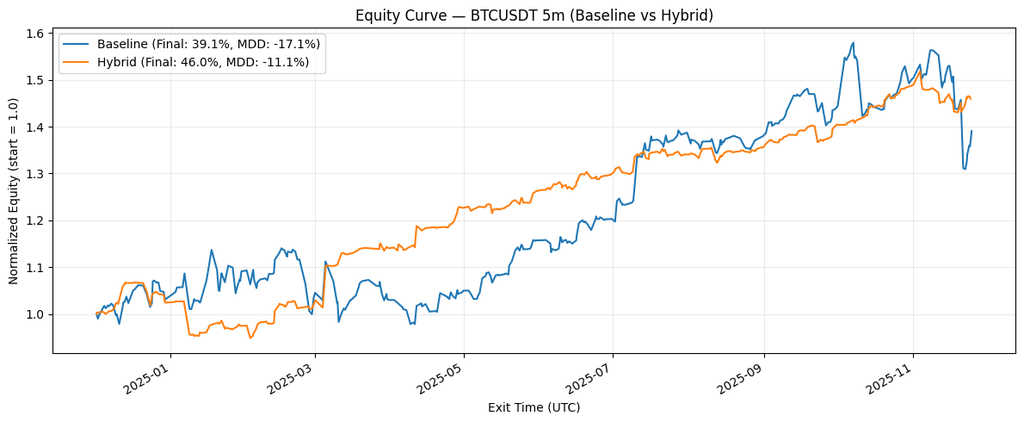

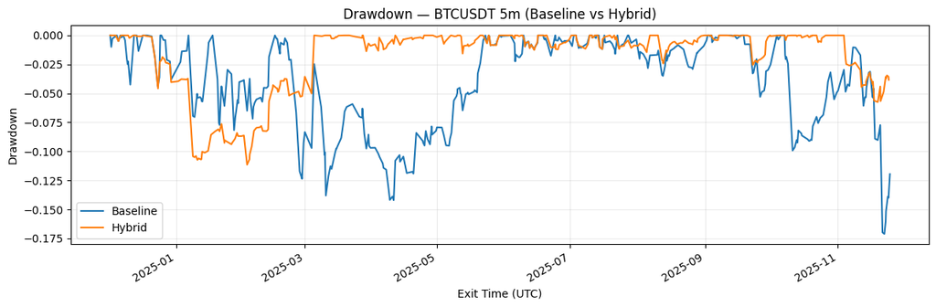

```
Baseline final return: 39.06% | MDD: -17.11%
Hybrid   final return: 45.96% | MDD: -11.15%
```

```python
import pandas as pd
import numpy as np
import matplotlib.pyplot as plt

# =========================
# 1) Load CSVs
# =========================
eq_base = pd.read_csv("equity_baseline_btc_5m.csv")
eq_hyb  = pd.read_csv("equity_hybrid_btc_5m.csv")
trades  = pd.read_csv("trades_compare_baseline_vs_hybrid.csv")

# =========================
# 2) Get equity series
# =========================
def find_col(df, candidates):
    lower_map = {c.lower(): c for c in df.columns}
    for cand in candidates:
        if cand.lower() in lower_map:
            return lower_map[cand.lower()]
    return None

col_eq_base = find_col(eq_base, ["equity", "equity_curve", "cum_equity", "equity_value"])
col_eq_hyb  = find_col(eq_hyb,  ["equity", "equity_curve", "cum_equity", "equity_value"])

assert col_eq_base is not None, f"No encontré columna de equity en baseline. Columnas: {eq_base.columns.tolist()}"
assert col_eq_hyb  is not None, f"No encontré columna de equity en hybrid. Columnas: {eq_hyb.columns.tolist()}"

y_base = pd.to_numeric(eq_base[col_eq_base], errors="coerce").astype(float).reset_index(drop=True)
y_hyb  = pd.to_numeric(eq_hyb[col_eq_hyb],  errors="coerce").astype(float).reset_index(drop=True)

# Normalizar a 1.0 (paper-friendly)
y_base = y_base / y_base.iloc[0]
y_hyb  = y_hyb  / y_hyb.iloc[0]

# =========================
# 3) Get time axis (exit times)
# =========================
t_base = pd.to_datetime(trades["exit_time_baseline"], utc=True)
t_hyb  = pd.to_datetime(trades["exit_time_hybrid"],  utc=True)

assert len(t_base) == len(y_base), f"Longitud baseline no coincide: t_base={len(t_base)} vs y_base={len(y_base)}"
assert len(t_hyb)  == len(y_hyb),  f"Longitud hybrid no coincide: t_hyb={len(t_hyb)} vs y_hyb={len(y_hyb)}"

# Ordenar por tiempo (por si acaso)
order_base = np.argsort(t_base.values)
order_hyb  = np.argsort(t_hyb.values)

t_base_sorted = t_base.iloc[order_base].reset_index(drop=True)
t_hyb_sorted  = t_hyb.iloc[order_hyb].reset_index(drop=True)

y_base_sorted = y_base.iloc[order_base].reset_index(drop=True)
y_hyb_sorted  = y_hyb.iloc[order_hyb].reset_index(drop=True)

# =========================
# 4) Drawdown helper
# =========================
def drawdown(equity):
    peak = equity.cummax()
    return equity / peak - 1.0

dd_base = drawdown(y_base_sorted)
dd_hyb  = drawdown(y_hyb_sorted)

final_base = float(y_base_sorted.iloc[-1] - 1.0)
final_hyb  = float(y_hyb_sorted.iloc[-1]  - 1.0)

mdd_base = float(dd_base.min())
mdd_hyb  = float(dd_hyb.min())

# =========================
# 5) Plot equity
# =========================
plt.figure(figsize=(12,5))
plt.plot(t_base_sorted, y_base_sorted, label=f"Baseline (Final: {final_base*100:.1f}%, MDD: {mdd_base*100:.1f}%)")
plt.plot(t_hyb_sorted,  y_hyb_sorted,  label=f"Hybrid (Final: {final_hyb*100:.1f}%, MDD: {mdd_hyb*100:.1f}%)")

plt.title("Equity Curve — BTCUSDT 5m (Baseline vs Hybrid)")
plt.xlabel("Exit Time (UTC)")
plt.ylabel("Normalized Equity (start = 1.0)")
plt.legend()
plt.grid(True, alpha=0.25)
plt.xticks(rotation=30, ha="right")
plt.tight_layout()
plt.show()

# =========================
# 6) Plot drawdown
# =========================
plt.figure(figsize=(12,4))
plt.plot(t_base_sorted, dd_base, label="Baseline")
plt.plot(t_hyb_sorted,  dd_hyb,  label="Hybrid")

plt.title("Drawdown — BTCUSDT 5m (Baseline vs Hybrid)")
plt.xlabel("Exit Time (UTC)")
plt.ylabel("Drawdown")
plt.legend()
plt.grid(True, alpha=0.25)
plt.xticks(rotation=30, ha="right")
plt.tight_layout()
plt.show()

print("Baseline final return:", f"{final_base*100:.2f}% | MDD:", f"{mdd_base*100:.2f}%")
print("Hybrid   final return:", f"{final_hyb*100:.2f}% | MDD:", f"{mdd_hyb*100:.2f}%")
```

## Resumen del modelo híbrido por régimen

En este cuaderno se desarrolló y evaluó una estrategia de *trading cuantitativo* para **BTCUSDT en marco temporal de 5 minutos**, basada originalmente en un modelo físico de momentum construido a partir de **derivadas discretas del precio** (momentum, velocidad y aceleración, junto con sus correspondientes *z-scores*).

El **modelo base** genera señales de entrada (*BUY*) y salida (*SELL*) mediante reglas estáticas basadas en cruces de `zspeed` y confirmación por `zaccel`. Si bien este enfoque logra capturar movimientos direccionales relevantes, el análisis empírico mostró una debilidad estructural: una proporción significativa del beneficio máximo alcanzado por cada trade (*Maximum Favorable Excursion*, MFE) es devuelta antes de ejecutar la salida, lo que se traduce en una mayor volatilidad de la curva de capital y *drawdowns* más profundos.

Para abordar este problema sin modificar las condiciones de entrada, se introdujo un **modelo híbrido de gestión de salidas dependiente del régimen del trade**. Este enfoque clasifica cada operación de manera temprana, utilizando únicamente la información de las primeras seis velas posteriores a la entrada, con el objetivo de distinguir entre **trades frágiles** (bajo *follow-through* inicial) y **trades convexos** (movimientos con continuidad direccional).

En el caso de trades clasificados como frágiles, se activa un **mecanismo de salida por deterioro**, basado en señales de pérdida de momentum (dos velas consecutivas con `zspeed < 0` y aceleración no positiva), permitiendo cerrar la posición antes de que el beneficio potencial se deteriore. Por el contrario, los trades no frágiles se mantienen hasta la señal de salida original del modelo base, preservando así la convexidad de los movimientos favorables.

Este modelo nuevo de regimenes no busca indicar cuando comprar o vender, sino lo que busca es como condicionar la gestion de salida dependiendo del regimen en el que se encuentre el trade, buscando mejorar la eficiencia de las salidas sin afectar las entradas originales del modelo base.